# National Trends in the Utilization of Mental Health Services among U.S. adults with Suicidal Ideation and Violent Behaviours

BMIN503/EPID600 Final Project

Author

Kian Lew

## 1 Overview

Data from the National Violent Death Reporting System (NVDRS) show an increasing prevalence of deaths due to violent behaviors, including suicide, homicide, and firearm-related incidents. The objectives of this study are: i) to describe the prevalence of past-year history of suicidal ideation (SI) or violent behaviors (VB) among U.S. adults; ii) to describe the trends in the utilization of mental health services among U.S. adults with SI and/or VB. iii) to describe the trends of perceived unmet need for mental health services among U.S. adults with SI and/or VB. iv) to describe the reasons of not seeking mental health treatment among U.S. adults with SI and/or VB. v) to identify factors (e.g., demographic , social, behavioral factors, psychiatry disorders associated with SI and/or VB. The dataset I am using is the National Survey on Drug Use and Health (NSDUH) from 2015 to 2021. The target population is U.S. adults aged 18–64 with past-year history of suicidal ideation or violent behaviors. Here is the [link](https://github.com/kianlew/BMIN5030_Final_Project) to my final project.

## 2 Introduction

According to the World Health Organization (WHO) and the Centers for Disease Control and Prevention (CDC)<sup>1</sup>, violence is defined as the intentional use of physical force or power, threatened or actual, against oneself, another person, or a group or community, that either results in or has a high likelihood of resulting in injury, death, psychological harm, maldevelopment, or deprivation. Statistics from the CDC National Violent Death Reporting System (NVDRS)<sup>2</sup> show an increasing prevalence of deaths due to violent behaviors including suicide, homicide, firearm-related incidents, and other forms of violence. This is an important public health issue because violent behavior not only causes harm to oneself but also disrupts the lives of others at a societal level.

There is a potentially strong link between these violent behaviors and mental illness, which warrants extensive research in this area. While there have been a few studies on mental health services utilization patterns among U.S. adults with suicidal ideation<sup>3,4,5</sup>, little is known about the mental health utilization patterns among U.S. adults with violent behaviors. In this regard, this study aims to better understand mental health service utilization among this vulnerable group, which could provide insights into the prevention of violence-related deaths.

This problem is interdisciplinary because it draws upon multiple fields to improve its understanding. Psychiatry contributes domain knowledge about mental illness and mental health services. Epidemiology provides methodologies to measure the prevalence of suicidal ideation, violent behaviors and utilization of mental health services. Multivariable logistic regression, which is used to identify the sociodemographic factors associated with the outcome SIVB, is a method in the field of biostatistics.

I had a fruitful discussion with Dr. Sherrie Xie who is an epidemiologist. I learned some new concepts in statistical analysis. These include transforming dummy variables into a single categorical variable, setting the reference using the relevel function, and measuring collinearity using the Variance Inflation Factor (VIF). In addition, I spoke with Dr. Jesse Hsu, who advised me to loop ‘YEAR’ as an interaction term with each of the sociodemographic factors and compare them to the baseline model. Then, forest plots can be used to visualize the odds ratios, illustrating the variation of sociodemographic factors across multiple years. Whereas with Professor David Oslin who is a professor of psychiatrist, he provided clinical insights that although the Affordable Care Act has increased access to mental health services, it often does not cover highly specialized treatments targeted at patients with suicidal ideation. As a result, patients must pay out-of-pocket to access these specialized services. That explains why the prevalence of suicidal ideation is increasing despite a rise in the utilization of mental health services. This is reflected in my findings that the most common reason for not seeking mental health treatment was cost barrier.

## 3 Methods

This is a retrospective cohort study based on the publicly available National Survey on Drug Use and Health (NSDUH) dataset from 2015 to 2021. The sample consists of adults (aged 18–64) residing in the United States. NSDUH provides nationally representative information through a stratified random sampling method based on sociodemographic and clinical characteristics (alcohol, tobacco, and drug use, mental health,and health-related issues). Details of the survey, including questionnaires, methodology, and a description of the dataset, are available on the NSDUH website.<sup>6</sup>

**Inclusion Criteria:** US adult aged between 18-64 years old with sucidal ideation(suicide thought, suicide plan, suicide attempt in the past 12 months ) or violent behaviors (attacked someone with the intention to seriously hurt them, arrest or booking history of arson, sex offense, assault, violent offense, robbery in the past 12 months).

**Sociodemographic factors of interest:** Age, Sex, Race/Hispanicity, Educational Attainment, Employment Status, Rurality, Health Insurance, Family Income, Personal Income, Marital Status, Heavy/Binge Drinking Habit, Illicit Drug Use, Alcohol Use Disorder, Drug Use Disorder, Major Depressive Episode, and Presence/Severity of Mental Illness

```r
# Load necessary libraries
library(readr)
library(dplyr)
library(tidyverse)
library(tidyr)

# Load the dataset and assign it to nsduh_2021
nsduh_2021 <- read_delim("C:/Users/kianl/OneDrive/Documents/Raw Data/NSDUH-2021-DS0001-bndl-data-tsv_v4/NSDUH_2021_Tab.txt", show_col_types = FALSE)

# Filter rows where the age group is 18-64 and variables of interest
nsduh_2021_s <- nsduh_2021 |>
  filter(CATAG6 %in% c(2, 3, 4, 5)) |>
  select(
    CATAG6, IRSEX, NEWRACE2, EDUHIGHCAT, IRWRKSTAT18, COUTYP4, IRINSUR4, IRFAMIN3,
    IRPINC3, IRMARIT, BNGDRKMON, HVYDRKMON, ILLYR, IRPYUD5ALC, UD5ILLANY, IRAMDEYR,     MICATPY, IRSUICTHNK, IRSUITRYYR, IRSUIPLANYR, RSKYFQDGR, SNYATTAK, RSKYFQTES,
    BKSEXNR, BKARSON, BKROB, BKSRVIOL, BKSMASLT, AMHTXAND4, AMHTXYR4, AMHINP2,
    AMHOUTP4, MHRNCOV2, MHRNBRS2, MHRTRAN2, MHRTIME2, AUUNNCOV, MHRWHER2,
    MHRNOHP2, AUUNCOST, MHRHAND2, AUUNCMIT, MHRJOBS2, MHRCMIT2, MHRCFID2, MHRFOUT2
  )


# Filter rows with suicidal ideation and violent behaviours
nsduh_2021_ss <- nsduh_2021_s |>
  filter(
    (BKARSON == 1 | BKROB == 1 | BKSEXNR == 1 | BKSMASLT == 1 | BKSRVIOL == 1 |
      IRSUICTHNK == 1 | IRSUIPLANYR == 1 | IRSUITRYYR == 1) |
    (SNYATTAK %in% c(2, 3, 4, 5))
  )


#----------------------------------------------------------------------------

# Load the dataset and assign it to nsduh_2020
nsduh_2020 <- read_delim("C:/Users/kianl/OneDrive/Documents/Raw Data/NSDUH-2020-DS0001-bndl-data-tsv_v1/NSDUH_2020_Tab.txt", show_col_types = FALSE)

# Filter rows where the age group is 18-64 and variables of interest
nsduh_2020_s <- nsduh_2020 |>
  filter(CATAG6 %in% c(2, 3, 4, 5)) |>
  select(
    CATAG6, IRSEX, NEWRACE2, EDUHIGHCAT, IRWRKSTAT18, COUTYP4, IRINSUR4, IRFAMIN3,
    IRPINC3, IRMARIT, BNGDRKMON, HVYDRKMON, ILLYR, ABODALC, UDPYILL, AMDEY2_U,
    MI_CAT_U, MHSUITHK, MHSUITRY, MHSUIPLN, RSKYFQDGR, SNYATTAK, RSKYFQTES, BKSEXNR     , BKARSON, BKROB, BKSRVIOL, BKSMASLT, AMHTXAND, AMHTXRC3, AMHINP2, AMHOUTP3,
    MHRNCOV2, MHRNBRS2, MHRTRAN2, MHRTIME2, AUUNNCOV, MHRWHER2, MHRNOHP2, AUUNCOST,     MHRHAND2, AUUNCMIT, MHRJOBS2, MHRCMIT2, MHRCFID2, MHRFOUT2
  )


# Filter rows with suicidal ideation and violent behaviours
nsduh_2020_ss <- nsduh_2020_s |>
  filter(
    MHSUITHK == 1 | MHSUITRY == 1 | MHSUIPLN == 1 |
    BKSEXNR == 1 | BKARSON == 1 |
    BKROB == 1 | BKSRVIOL == 1 | BKSMASLT == 1 |
    SNYATTAK %in% c(2, 3, 4, 5)
  )


#----------------------------------------------------------------------------


# Load the dataset and assign it to nsduh_2019
nsduh_2019 <- read_delim("C:/Users/kianl/OneDrive/Documents/Raw Data/NSDUH-2019-DS0001-bndl-data-tsv/NSDUH_2019_Tab.txt", show_col_types = FALSE)

# Filter rows where the age group is 18-64 and variables of interest
nsduh_2019_s <- nsduh_2019 |>
  filter(CATAG6 %in% c(2, 3, 4, 5)) |>
  select(
    CATAG6, IRSEX, NEWRACE2, EDUHIGHCAT, IRWRKSTAT18, COUTYP4, IRINSUR4, IRFAMIN3,
    IRPINC3, IRMARIT, BNGDRKMON, HVYDRKMON, ILLYR, ABODALC, UDPYILL, AMDEY2_U,
    MI_CAT_U, MHSUITHK, MHSUITRY, MHSUIPLN, RSKYFQDGR, SNYATTAK, RSKYFQTES,
    BKSEXNR, BKARSON, BKROB, BKSRVIOL, BKSMASLT, AMHTXAND, AMHTXRC3, AMHINP2,
    AMHOUTP3, MHRNCOV2, MHRNBRS2, MHRTRAN2, MHRTIME2, AUUNNCOV, MHRWHER2,
    MHRNOHP2, AUUNCOST, MHRHAND2, AUUNCMIT, MHRJOBS2, MHRCMIT2, MHRCFID2, MHRFOUT2
  )


# Filter rows with suicidal ideation and violent behaviours
nsduh_2019_ss <- nsduh_2019_s |>
  filter(
    MHSUITHK == 1 | MHSUITRY == 1 | MHSUIPLN == 1 |
    BKSEXNR == 1 | BKARSON == 1 |
    BKROB == 1 | BKSRVIOL == 1 | BKSMASLT == 1 |
    SNYATTAK %in% c(2, 3, 4, 5)
  )


#-----------------------------------------------------------------------------

# Load the dataset and assign it to nsduh_2018
nsduh_2018 <- read_delim("C:/Users/kianl/OneDrive/Documents/Raw Data/NSDUH-2018-DS0001-bndl-data-tsv/NSDUH_2018_Tab.tsv", show_col_types = FALSE)

# Filter rows where the age group is 18-64 and variables of interest
nsduh_2018_s <- nsduh_2018 |>
  filter(CATAG6 %in% c(2, 3, 4, 5)) |>
  select(
    CATAG6, IRSEX, NEWRACE2, EDUHIGHCAT, IRWRKSTAT18, COUTYP4, IRINSUR4, IRFAMIN3,
    IRPINC3, IRMARIT, BNGDRKMON, HVYDRKMON, ILLYR, ABODALC, UDPYILL, AMDEY2_U,
    MI_CAT_U, MHSUITHK, MHSUITRY, MHSUIPLN, RSKYFQDGR, SNYATTAK, RSKYFQTES, BKSEXNR
    , BKARSON, BKROB, BKSRVIOL, BKSMASLT, AMHTXAND, AMHTXRC3, AMHINP2, AMHOUTP3,
    MHRNCOV2, MHRNBRS2, MHRTRAN2, MHRTIME2, AUUNNCOV, MHRWHER2, MHRNOHP2, AUUNCOST,     MHRHAND2, AUUNCMIT, MHRJOBS2, MHRCMIT2, MHRCFID2, MHRFOUT2
  )


# Filter rows with suicidal ideation and violent behaviours
nsduh_2018_ss <- nsduh_2018_s |>
  filter(
    MHSUITHK == 1 | MHSUITRY == 1 | MHSUIPLN == 1 |
    BKSEXNR == 1 | BKARSON == 1 |
    BKROB == 1 | BKSRVIOL == 1 | BKSMASLT == 1 |
    SNYATTAK %in% c(2, 3, 4, 5)
  )


#-----------------------------------------------------------------------------


# Load the dataset and assign it to nsduh_2017
nsduh_2017 <- read_delim("C:/Users/kianl/OneDrive/Documents/Raw Data/NSDUH-2017-DS0001-bndl-data-tsv/NSDUH_2017_Tab.tsv", show_col_types = FALSE)

# Filter rows where the age group is 18-64 and variables of interest
nsduh_2017_s <- nsduh_2017 |>
  filter(CATAG6 %in% c(2, 3, 4, 5)) |>
  select(
    CATAG6, IRSEX, NEWRACE2, EDUHIGHCAT, IRWRKSTAT18, COUTYP4, IRINSUR4, IRFAMIN3,
    IRPINC3, IRMARIT, BNGDRKMON, HVYDRKMON, ILLYR, ABODALC, UDPYILL, AMDEY2_U,
    MI_CAT_U, MHSUITHK, MHSUITRY, MHSUIPLN, RSKYFQDGR, SNYATTAK, RSKYFQTES,
    BKSEXNR, BKARSON, BKROB, BKSRVIOL, BKSMASLT, AMHTXAND, AMHTXRC3, AMHINP2,
    AMHOUTP3, MHRNCOV2, MHRNBRS2, MHRTRAN2, MHRTIME2, AUUNNCOV, MHRWHER2,
    MHRNOHP2, AUUNCOST, MHRHAND2, AUUNCMIT, MHRJOBS2, MHRCMIT2, MHRCFID2, MHRFOUT2
  )


# Filter rows with suicidal ideation and violent behaviours
nsduh_2017_ss <- nsduh_2017_s |>
  filter(
    MHSUITHK == 1 | MHSUITRY == 1 | MHSUIPLN == 1 |
    BKSEXNR == 1 | BKARSON == 1 |
    BKROB == 1 | BKSRVIOL == 1 | BKSMASLT == 1 |
    SNYATTAK %in% c(2, 3, 4, 5)
  )

#----------------------------------------------------------------------------

# Load the dataset and assign it to nsduh_2016
nsduh_2016 <- read_delim("C:/Users/kianl/OneDrive/Documents/Raw Data/NSDUH-2016-DS0001-bndl-data-tsv/NSDUH_2016_Tab.tsv", show_col_types = FALSE)

# Filter rows where the age group is 18-64 and variables of interest
nsduh_2016_s <- nsduh_2016 |>
  filter(CATAG6 %in% c(2, 3, 4, 5)) |>
  select(
    CATAG6, IRSEX, NEWRACE2, EDUHIGHCAT, IRWRKSTAT18, COUTYP4, IRINSUR4, IRFAMIN3,
    IRPINC3, IRMARIT, BNGDRKMON, HVYDRKMON, ILLYR, ABODALC, UDPYILL, AMDEY2_U,
    MI_CAT_U, MHSUITHK, MHSUITRY, MHSUIPLN, RSKYFQDGR, SNYATTAK, RSKYFQTES,
    BKSEXNR, BKARSON, BKROB, BKSRVIOL, BKSMASLT, AMHTXAND, AMHTXRC3, AMHINP2,
    AMHOUTP3, MHRNCOV2, MHRNBRS2, MHRTRAN2, MHRTIME2, AUUNNCOV, MHRWHER2,
    MHRNOHP2, AUUNCOST, MHRHAND2, AUUNCMIT, MHRJOBS2, MHRCMIT2, MHRCFID2, MHRFOUT2
  )


# Filter rows with suicidal ideation and violent behaviours
nsduh_2016_ss <- nsduh_2016_s |>
  filter(
    MHSUITHK == 1 | MHSUITRY == 1 | MHSUIPLN == 1 |
    BKSEXNR == 1 | BKARSON == 1 |
    BKROB == 1 | BKSRVIOL == 1 | BKSMASLT == 1 |
    SNYATTAK %in% c(2, 3, 4, 5)
  )


#------------------------------------------------------------------------------

# Load the dataset and assign it to nsduh_2015
nsduh_2015 <- read_delim("C:/Users/kianl/OneDrive/Documents/Raw Data/NSDUH-2015-DS0001-bndl-data-tsv/NSDUH_2015_Tab.tsv", show_col_types = FALSE)

# Filter rows where the age group is 18-64 and variables of interest
nsduh_2015_s <- nsduh_2015 |>
  filter(CATAG6 %in% c(2, 3, 4, 5)) |>
  select(
    CATAG6, IRSEX, NEWRACE2, EDUHIGHCAT, IRWRKSTAT18, COUTYP4, IRINSUR4, IRFAMIN3,
    IRPINC3, IRMARITSTAT, BNGDRKMON, HVYDRKMON, ILLYR, ABODALC, UDPYILL, AMDEY2_U,
    MI_CAT_U, MHSUITHK, MHSUITRY, MHSUIPLN, RSKYFQDGR, SNYATTAK, RSKYFQTES,
    BKSEXNR, BKARSON, BKROB, BKSRVIOL, BKSMASLT, AMHTXAND, AMHTXRC3, AMHINP2,
    AMHOUTP3, MHRNCOV2, MHRNBRS2, MHRTRAN2, MHRTIME2, AUUNNCOV, MHRWHER2,
    MHRNOHP2, AUUNCOST, MHRHAND2, AUUNCMIT, MHRJOBS2, MHRCMIT2, MHRCFID2, MHRFOUT2
  )


# Filter rows with suicidal ideation and violent behaviours
nsduh_2015_ss <- nsduh_2015_s |>
  filter(
    MHSUITHK == 1 | MHSUITRY == 1 | MHSUIPLN == 1 |
    BKSEXNR == 1 | BKARSON == 1 |
    BKROB == 1 | BKSRVIOL == 1 | BKSMASLT == 1 |
    SNYATTAK %in% c(2, 3, 4, 5)
  )
```

Data preparation: The dataset from 2015 to 2021 is combined, then the datasets needed for analyses are created-Suicidal Ideation and Violent Behaviour (SIVB), Suicidal Ideation only(SI), Violent Behaviour (VB) for the analyses of prevalence of these three groups and multivariable logistics regression .

```r
library(data.table)

# List of datasets from 2015 to 2021
dataset_list <- list(
  nsduh_2015_ss,
  nsduh_2016_ss,
  nsduh_2017_ss,
  nsduh_2018_ss,
  nsduh_2019_ss,
  nsduh_2020_ss,
  nsduh_2021_ss
)

years <- 2015:2021

# Convert datasets to data.tables and add YEAR column
dt_list <- mapply(function(df, year) {
  dt <- as.data.table(df)
  dt[, YEAR := year]
  return(dt)
}, dataset_list, years, SIMPLIFY = FALSE)

# Combine datasets from 2015 to 2021
combined_dt <- rbindlist(dt_list, use.names = FALSE)

# Get column names from the 2021 dataset and add 'YEAR'
colnames_2021 <- c(names(nsduh_2021_ss), "YEAR")

# Assign column names to the combined dataset
setnames(combined_dt, colnames_2021)

# Convert the combined data.table to a data.frame
combined_nsduh_ss <- as.data.frame(combined_dt)

#------------------------------------------------------------------------------

 #List of your datasets from 2015 to 2021
dataset_list <- list(
  nsduh_2015_s,
  nsduh_2016_s,
  nsduh_2017_s,
  nsduh_2018_s,
  nsduh_2019_s,
  nsduh_2020_s,
  nsduh_2021_s
  )
years <- 2015:2021

# Convert datasets to data.tables and add YEAR column
dt_list <- mapply(function(df, year) {
  dt <- as.data.table(df)
  dt[, YEAR := year]
  return(dt) }, dataset_list, years, SIMPLIFY = FALSE)

# Combine datasets
combined_dt <- rbindlist(dt_list, use.names = FALSE)

# Get column names from the 2021 dataset and add 'YEAR'
colnames_2022 <- c(names(nsduh_2021_s), "YEAR")

# Assign column names to the combined dataset
setnames(combined_dt, colnames_2021)

# Convert the combined data.table to a data.frame
combined_nsduh_s <- as.data.frame(combined_dt)

#-------------------------------------------------------------------------------
# Create the SI dataset
combined_nsduh_si <- combined_nsduh_s |>
  mutate(
    # SI is 1 if any of the variables is 1, else 0
    SI = ifelse(
      IRSUICTHNK == 1 |
      IRSUITRYYR == 1 |
      IRSUIPLANYR == 1,
      1,
      0
    ),

    # HB_DRINKING is 1 if either BNGDRKMON or HVYDRKMON is 1, else 0
    HB_DRINKING = ifelse(
      BNGDRKMON == 1 | HVYDRKMON == 1,
      1,
      0
    )
  )

#--------------------------------------------------------------------------

# Create the VB dataset
combined_nsduh_vb <- combined_nsduh_s |>
  mutate(
    # VB is 1 if any of the variables is 1, else 0
    VB = ifelse(
      SNYATTAK %in% c(2, 3, 4, 5) |
      BKSEXNR == 1 |
      BKARSON == 1 |
      BKROB == 1 |
      BKSRVIOL == 1 |
      BKSMASLT == 1,
      1,
      0
    ),

    # HB_DRINKING is 1 if either BNGDRKMON or HVYDRKMON is 1, else 0
    HB_DRINKING = ifelse(
      BNGDRKMON == 1 | HVYDRKMON == 1,
      1,
      0
    )
  )


#---------------------------------------------------------------------------

# Create the SIVB dataset
combined_nsduh_sv <- combined_nsduh_s |>
  mutate(
    # SI_VB is 1 if any of the variables is 1, else 0
    SI_VB = ifelse(
      IRSUICTHNK == 1 |
      IRSUITRYYR == 1 |
      IRSUIPLANYR == 1 |
      SNYATTAK %in% c(2, 3, 4, 5) |
      BKSEXNR == 1 |
      BKARSON == 1 |
      BKROB == 1 |
      BKSRVIOL == 1 |
      BKSMASLT == 1,
      1,
      0
    ),

    # HB_DRINKING is 1 if either BNGDRKMON or HVYDRKMON is 1, else 0
    HB_DRINKING = ifelse(
      BNGDRKMON == 1 | HVYDRKMON == 1,
      1,
      0
    )
  )
```

Data preparation: The dataset for the analysis of utilization of mental health services for three groups-Suicidal Ideation and Violent Behaviour (SIVB), Suicidal Ideation (SI), Violent Behaviour (VB) are created.

```r
# Create the dataset for utilization of mental health services analysis
combined_nsduh_svhb <- combined_nsduh_ss |>
  mutate(
    # SI_VB is 1 if any of the variables is 1, else 0
    SI_VB = ifelse(
      IRSUICTHNK == 1 |
      IRSUITRYYR == 1 |
      IRSUIPLANYR == 1 |
      SNYATTAK %in% c(2, 3, 4, 5) |
      BKSEXNR == 1 |
      BKARSON == 1 |
      BKROB == 1 |
      BKSRVIOL == 1 |
      BKSMASLT == 1,
      1,
      0
    ),

    # SIaVB is 1 if SI and VB is 1, else 0
    SIaVB = ifelse(
      (IRSUICTHNK == 1 |
      IRSUITRYYR == 1 |
      IRSUIPLANYR == 1  ) &
      (SNYATTAK %in% c(2, 3, 4, 5) |
      BKSEXNR == 1 |
      BKARSON == 1 |
      BKROB == 1 |
      BKSRVIOL == 1 |
      BKSMASLT == 1),
      1,
      0
    ),

    # SI is 1 if any of the variables is 1, else 0
    SI = ifelse(
      IRSUICTHNK == 1 |
      IRSUITRYYR == 1 |
      IRSUIPLANYR == 1,
      1,
      0
    ),

    # VB is 1 if any of the variables is 1, else 0
    VB = ifelse(
      SNYATTAK %in% c(2, 3, 4, 5) |
      BKSEXNR == 1 |
      BKARSON == 1 |
      BKROB == 1 |
      BKSRVIOL == 1 |
      BKSMASLT == 1,
      1,
      0
    ),

    # HB_DRINKING is 1 if either BNGDRKMON or HVYDRKMON is 1, else 0
    HB_DRINKING = ifelse(
      BNGDRKMON == 1 | HVYDRKMON == 1,
      1,
      0
    )
  )
```

## 4 Results

Table 1: Summary of the sociodemographics characteristics of study sample

```r
# Load necessary packages
library(gtsummary)
library(gt)

# Assign descriptive labels to each categorical variable
combined_nsduh_svhbd <- combined_nsduh_svhb |>
  mutate(
    CATAG6 = factor(
      CATAG6,
      levels = 2:5,
      labels = c(
        "18-25 Years Old",
        "26-34 Years Old",
        "35-49 Years Old",
        "50-64 Years Old"
      )
    ),
    IRSEX = factor(IRSEX, levels = 1:2, labels = c("Male", "Female")),
    NEWRACE2 = factor(
      NEWRACE2,
      levels = 1:7,
      labels = c(
        "White",
        "Black/African American",
        "Native American/Alaskan",
        "Hawaiian/Pacific Islander",
        "Asian",
        "Mixed",
        "Hispanic"
      )
    ),
    EDUHIGHCAT = factor(
      EDUHIGHCAT,
      levels = 1:4,
      labels = c(
        "< High school",
        "High school",
        "Associate degree",
        "College graduate"
      )
    ),
    IRWRKSTAT18 = factor(
      IRWRKSTAT18,
      levels = 1:4,
      labels = c(
        "Full-time",
        "Part-time",
        "Unemployed",
        "Others"
      )
    ),
    COUTYP4 = factor(
      COUTYP4,
      levels = 1:3,
      labels = c("Large Metro", "Small Metro", "Nonmetro")
    ),
    IRINSUR4 = factor(IRINSUR4, levels = 1:2, labels = c("Yes", "No")),
    IRFAMIN3 = factor(
      IRFAMIN3,
      levels = 1:7,
      labels = c(
        "< $10,000",
        "$10,000 - $19,999",
        "$20,000 - $29,999",
        "$30,000 - $39,999",
        "$40,000 - $49,999",
        "$50,000 - $74,999",
        "$75,000 or more"
      )
    ),
    IRPINC3 = factor(
      IRPINC3,
      levels = 1:7,
      labels = c(
        "< $10,000",
        "$10,000 - $19,999",
        "$20,000 - $29,999",
        "$30,000 - $39,999",
        "$40,000 - $49,999",
        "$50,000 - $74,999",
        "> $75,000"
      )
    ),
    IRMARIT = factor(
      IRMARIT,
      levels = 1:4,
      labels = c(
        "Married",
        "Widowed",
        "Divorced/Separated",
        "Never Been Married"
      )
    ),
    HB_DRINKING = factor(HB_DRINKING, levels = 0:1, labels = c("No", "Yes")),
    ILLYR = factor(ILLYR, levels = 0:1, labels = c("No", "Yes")),
    IRPYUD5ALC = factor(IRPYUD5ALC, levels = 0:1, labels = c("No", "Yes")),
    UD5ILLANY = factor(UD5ILLANY, levels = 0:1, labels = c("No", "Yes")),
    IRAMDEYR = factor(IRAMDEYR, levels = 0:1, labels = c("No", "Yes")),
    MICATPY = factor(
      MICATPY,
      levels = 0:3,
      labels = c("No", "Mild", "Moderate", "Serious")
    )
  )

# Create Descriptive Summary Table by YEAR
summary_table <- combined_nsduh_svhbd |>
  select(
    YEAR,
    CATAG6,
    IRSEX,
    NEWRACE2,
    EDUHIGHCAT,
    IRWRKSTAT18,
    COUTYP4,
    IRINSUR4,
    IRFAMIN3,
    IRPINC3,
    IRMARIT,
    HB_DRINKING,
    ILLYR,
    IRPYUD5ALC,
    UD5ILLANY,
    IRAMDEYR,
    MICATPY
  ) |>
  tbl_summary(
    by = YEAR,
    label = list(
      CATAG6 ~ "Age",
      IRSEX ~ "Sex",
      NEWRACE2 ~ "Race/Hispanicity",
      EDUHIGHCAT ~ "Educational Attainment",
      IRWRKSTAT18 ~ "Employment Status",
      COUTYP4 ~ "Rurality",
      IRINSUR4 ~ "Health Insurance",
      IRFAMIN3 ~ "Family Income",
      IRPINC3 ~ "Personal Income",
      IRMARIT ~ "Marital Status",
      HB_DRINKING ~ "Heavy/Binge Drinking Habit",
      ILLYR ~ "Illicit Drug Use",
      IRPYUD5ALC ~ "Alcohol Use Disorder",
      UD5ILLANY ~ "Drug Use Disorder",
      IRAMDEYR ~ "Major Depressive Episode",
      MICATPY ~ "Presence/Severity of Mental Illness"
    ),
    type = all_categorical() ~ "categorical",
    statistic = all_categorical() ~ "{n} / {N} ({p}%)",
    missing = "no"
  ) |>
  modify_spanning_header(starts_with("stat_") ~ "**Year**") |>
  modify_caption("**Table 2: Summary of Descriptive Statistics of Sociodemographics by Year**") |>
  bold_labels() |>
  modify_header(
    label ~ "**Sociodemographics** &nbsp;&nbsp;&nbsp;&nbsp;&nbsp;&nbsp;&nbsp;&nbsp;&nbsp;&nbsp;&nbsp;&nbsp;&nbsp;&nbsp;&nbsp;&nbsp;&nbsp;&nbsp;&nbsp;&nbsp;&nbsp;&nbsp;                                         (N = 21,176)"
  ) |>
  modify_footnote(
    everything() ~ NA_character_
  )

# Convert to gt table
summary_table_gt <- summary_table |>
  as_gt()

# Adjust column width
summary_table_gt <- summary_table_gt |>
  cols_width(
    label ~ px(500)
  )

# Change the font size to small
summary_table_gt <- summary_table_gt |>
  tab_options(
    table.font.size = "small"
  )

# Display the Final Table
summary_table_gt
```

**Table 2: Summary of Descriptive Statistics of Sociodemographics by Year**

| **Sociodemographics** (N = 21,176) | **Year** **2015** N = 3,014 | **Year** **2016** N = 2,918 | **Year** **2017** N = 3,064 | **Year** **2018** N = 3,159 | **Year** **2019** N = 3,437 | **Year** **2020** N = 1,978 | **Year** **2021** N = 3,606 |
| --- | --- | --- | --- | --- | --- | --- | --- |
| Age |  |  |  |  |  |  |  |
| 18-25 Years Old | 1,658 / 3014 (55%) | 1,591 / 2918 (55%) | 1,753 / 3064 (57%) | 1,797 / 3159 (57%) | 1,998 / 3437 (58%) | 1,021 / 1978 (52%) | 1,899 / 3606 (53%) |
| 26-34 Years Old | 588 / 3014 (20%) | 589 / 2918 (20%) | 603 / 3064 (20%) | 627 / 3159 (20%) | 690 / 3437 (20%) | 460 / 1978 (23%) | 764 / 3606 (21%) |
| 35-49 Years Old | 561 / 3014 (19%) | 563 / 2918 (19%) | 524 / 3064 (17%) | 557 / 3159 (18%) | 578 / 3437 (17%) | 374 / 1978 (19%) | 739 / 3606 (20%) |
| 50-64 Years Old | 207 / 3014 (6.9%) | 175 / 2918 (6.0%) | 184 / 3064 (6.0%) | 178 / 3159 (5.6%) | 171 / 3437 (5.0%) | 123 / 1978 (6.2%) | 204 / 3606 (5.7%) |
| Sex |  |  |  |  |  |  |  |
| Male | 1,345 / 3014 (45%) | 1,351 / 2918 (46%) | 1,368 / 3064 (45%) | 1,424 / 3159 (45%) | 1,527 / 3437 (44%) | 810 / 1978 (41%) | 1,440 / 3606 (40%) |
| Female | 1,669 / 3014 (55%) | 1,567 / 2918 (54%) | 1,696 / 3064 (55%) | 1,735 / 3159 (55%) | 1,910 / 3437 (56%) | 1,168 / 1978 (59%) | 2,166 / 3606 (60%) |
| Race/Hispanicity |  |  |  |  |  |  |  |
| White | 1,722 / 3014 (57%) | 1,716 / 2918 (59%) | 1,817 / 3064 (59%) | 1,863 / 3159 (59%) | 2,017 / 3437 (59%) | 1,307 / 1978 (66%) | 2,140 / 3606 (59%) |
| Black/African American | 443 / 3014 (15%) | 432 / 2918 (15%) | 394 / 3064 (13%) | 424 / 3159 (13%) | 417 / 3437 (12%) | 149 / 1978 (7.5%) | 412 / 3606 (11%) |
| Native American/Alaskan | 77 / 3014 (2.6%) | 69 / 2918 (2.4%) | 67 / 3064 (2.2%) | 71 / 3159 (2.2%) | 69 / 3437 (2.0%) | 21 / 1978 (1.1%) | 60 / 3606 (1.7%) |
| Hawaiian/Pacific Islander | 11 / 3014 (0.4%) | 11 / 2918 (0.4%) | 20 / 3064 (0.7%) | 16 / 3159 (0.5%) | 22 / 3437 (0.6%) | 10 / 1978 (0.5%) | 18 / 3606 (0.5%) |
| Asian | 88 / 3014 (2.9%) | 82 / 2918 (2.8%) | 88 / 3064 (2.9%) | 103 / 3159 (3.3%) | 122 / 3437 (3.5%) | 90 / 1978 (4.6%) | 145 / 3606 (4.0%) |
| Mixed | 191 / 3014 (6.3%) | 148 / 2918 (5.1%) | 195 / 3064 (6.4%) | 181 / 3159 (5.7%) | 194 / 3437 (5.6%) | 126 / 1978 (6.4%) | 233 / 3606 (6.5%) |
| Hispanic | 482 / 3014 (16%) | 460 / 2918 (16%) | 483 / 3064 (16%) | 501 / 3159 (16%) | 596 / 3437 (17%) | 275 / 1978 (14%) | 598 / 3606 (17%) |
| Educational Attainment |  |  |  |  |  |  |  |
| < High school | 525 / 3014 (17%) | 485 / 2918 (17%) | 478 / 3064 (16%) | 456 / 3159 (14%) | 443 / 3437 (13%) | 188 / 1978 (9.5%) | 433 / 3606 (12%) |
| High school | 937 / 3014 (31%) | 846 / 2918 (29%) | 885 / 3064 (29%) | 960 / 3159 (30%) | 1,042 / 3437 (30%) | 465 / 1978 (24%) | 1,003 / 3606 (28%) |
| Associate degree | 1,133 / 3014 (38%) | 1,170 / 2918 (40%) | 1,260 / 3064 (41%) | 1,241 / 3159 (39%) | 1,398 / 3437 (41%) | 771 / 1978 (39%) | 1,321 / 3606 (37%) |
| College graduate | 419 / 3014 (14%) | 417 / 2918 (14%) | 441 / 3064 (14%) | 502 / 3159 (16%) | 554 / 3437 (16%) | 554 / 1978 (28%) | 849 / 3606 (24%) |
| Employment Status |  |  |  |  |  |  |  |
| Full-time | 1,259 / 3014 (42%) | 1,170 / 2918 (40%) | 1,358 / 3064 (44%) | 1,417 / 3159 (45%) | 1,583 / 3437 (46%) | 840 / 1978 (42%) | 1,488 / 3606 (41%) |
| Part-time | 597 / 3014 (20%) | 618 / 2918 (21%) | 573 / 3064 (19%) | 628 / 3159 (20%) | 677 / 3437 (20%) | 404 / 1978 (20%) | 711 / 3606 (20%) |
| Unemployed | 374 / 3014 (12%) | 380 / 2918 (13%) | 347 / 3064 (11%) | 325 / 3159 (10%) | 382 / 3437 (11%) | 210 / 1978 (11%) | 425 / 3606 (12%) |
| Others | 784 / 3014 (26%) | 750 / 2918 (26%) | 786 / 3064 (26%) | 789 / 3159 (25%) | 795 / 3437 (23%) | 524 / 1978 (26%) | 982 / 3606 (27%) |
| Rurality |  |  |  |  |  |  |  |
| Large Metro | 1,345 / 3014 (45%) | 1,242 / 2918 (43%) | 1,280 / 3064 (42%) | 1,355 / 3159 (43%) | 1,423 / 3437 (41%) | 810 / 1978 (41%) | 1,492 / 3606 (41%) |
| Small Metro | 1,082 / 3014 (36%) | 1,075 / 2918 (37%) | 1,134 / 3064 (37%) | 1,163 / 3159 (37%) | 1,321 / 3437 (38%) | 797 / 1978 (40%) | 1,433 / 3606 (40%) |
| Nonmetro | 587 / 3014 (19%) | 601 / 2918 (21%) | 650 / 3064 (21%) | 641 / 3159 (20%) | 693 / 3437 (20%) | 371 / 1978 (19%) | 681 / 3606 (19%) |
| Health Insurance |  |  |  |  |  |  |  |
| Yes | 2,521 / 3014 (84%) | 2,471 / 2918 (85%) | 2,620 / 3064 (86%) | 2,701 / 3159 (86%) | 2,894 / 3437 (84%) | 1,704 / 1978 (86%) | 3,089 / 3606 (86%) |
| No | 493 / 3014 (16%) | 447 / 2918 (15%) | 444 / 3064 (14%) | 458 / 3159 (14%) | 543 / 3437 (16%) | 274 / 1978 (14%) | 517 / 3606 (14%) |
| Family Income |  |  |  |  |  |  |  |
| < $10,000 | 502 / 3014 (17%) | 463 / 2918 (16%) | 435 / 3064 (14%) | 427 / 3159 (14%) | 435 / 3437 (13%) | 256 / 1978 (13%) | 475 / 3606 (13%) |
| $10,000 - $19,999 | 511 / 3014 (17%) | 468 / 2918 (16%) | 480 / 3064 (16%) | 474 / 3159 (15%) | 504 / 3437 (15%) | 249 / 1978 (13%) | 505 / 3606 (14%) |
| $20,000 - $29,999 | 375 / 3014 (12%) | 377 / 2918 (13%) | 378 / 3064 (12%) | 409 / 3159 (13%) | 385 / 3437 (11%) | 209 / 1978 (11%) | 418 / 3606 (12%) |
| $30,000 - $39,999 | 353 / 3014 (12%) | 307 / 2918 (11%) | 344 / 3064 (11%) | 341 / 3159 (11%) | 383 / 3437 (11%) | 225 / 1978 (11%) | 374 / 3606 (10%) |
| $40,000 - $49,999 | 288 / 3014 (9.6%) | 288 / 2918 (9.9%) | 303 / 3064 (9.9%) | 330 / 3159 (10%) | 386 / 3437 (11%) | 188 / 1978 (9.5%) | 376 / 3606 (10%) |
| $50,000 - $74,999 | 358 / 3014 (12%) | 385 / 2918 (13%) | 416 / 3064 (14%) | 398 / 3159 (13%) | 484 / 3437 (14%) | 299 / 1978 (15%) | 508 / 3606 (14%) |
| $75,000 or more | 627 / 3014 (21%) | 630 / 2918 (22%) | 708 / 3064 (23%) | 780 / 3159 (25%) | 860 / 3437 (25%) | 552 / 1978 (28%) | 950 / 3606 (26%) |
| Personal Income |  |  |  |  |  |  |  |
| < $10,000 | 1,400 / 3014 (46%) | 1,349 / 2918 (46%) | 1,349 / 3064 (44%) | 1,347 / 3159 (43%) | 1,438 / 3437 (42%) | 707 / 1978 (36%) | 1,367 / 3606 (38%) |
| $10,000 - $19,999 | 755 / 3014 (25%) | 679 / 2918 (23%) | 740 / 3064 (24%) | 726 / 3159 (23%) | 769 / 3437 (22%) | 406 / 1978 (21%) | 769 / 3606 (21%) |
| $20,000 - $29,999 | 321 / 3014 (11%) | 330 / 2918 (11%) | 350 / 3064 (11%) | 401 / 3159 (13%) | 436 / 3437 (13%) | 245 / 1978 (12%) | 465 / 3606 (13%) |
| $30,000 - $39,999 | 177 / 3014 (5.9%) | 187 / 2918 (6.4%) | 233 / 3064 (7.6%) | 253 / 3159 (8.0%) | 301 / 3437 (8.8%) | 202 / 1978 (10%) | 311 / 3606 (8.6%) |
| $40,000 - $49,999 | 123 / 3014 (4.1%) | 114 / 2918 (3.9%) | 121 / 3064 (3.9%) | 155 / 3159 (4.9%) | 182 / 3437 (5.3%) | 121 / 1978 (6.1%) | 208 / 3606 (5.8%) |
| $50,000 - $74,999 | 133 / 3014 (4.4%) | 143 / 2918 (4.9%) | 162 / 3064 (5.3%) | 167 / 3159 (5.3%) | 186 / 3437 (5.4%) | 155 / 1978 (7.8%) | 256 / 3606 (7.1%) |
| > $75,000 | 105 / 3014 (3.5%) | 116 / 2918 (4.0%) | 109 / 3064 (3.6%) | 110 / 3159 (3.5%) | 125 / 3437 (3.6%) | 142 / 1978 (7.2%) | 230 / 3606 (6.4%) |
| Marital Status |  |  |  |  |  |  |  |
| Married | 611 / 3014 (20%) | 578 / 2918 (20%) | 596 / 3064 (19%) | 618 / 3159 (20%) | 625 / 3437 (18%) | 437 / 1978 (22%) | 774 / 3606 (21%) |
| Widowed | 103 / 3014 (3.4%) | 29 / 2918 (1.0%) | 19 / 3064 (0.6%) | 24 / 3159 (0.8%) | 27 / 3437 (0.8%) | 11 / 1978 (0.6%) | 25 / 3606 (0.7%) |
| Divorced/Separated | 361 / 3014 (12%) | 349 / 2918 (12%) | 313 / 3064 (10%) | 337 / 3159 (11%) | 328 / 3437 (9.5%) | 177 / 1978 (8.9%) | 380 / 3606 (11%) |
| Never Been Married | 1,939 / 3014 (64%) | 1,962 / 2918 (67%) | 2,136 / 3064 (70%) | 2,180 / 3159 (69%) | 2,457 / 3437 (71%) | 1,353 / 1978 (68%) | 2,427 / 3606 (67%) |
| Heavy/Binge Drinking Habit |  |  |  |  |  |  |  |
| No | 1,686 / 3014 (56%) | 1,779 / 2918 (61%) | 1,802 / 3064 (59%) | 1,953 / 3159 (62%) | 2,069 / 3437 (60%) | 1,285 / 1978 (65%) | 2,374 / 3606 (66%) |
| Yes | 1,328 / 3014 (44%) | 1,139 / 2918 (39%) | 1,262 / 3064 (41%) | 1,206 / 3159 (38%) | 1,368 / 3437 (40%) | 693 / 1978 (35%) | 1,232 / 3606 (34%) |
| Illicit Drug Use |  |  |  |  |  |  |  |
| No | 1,427 / 3014 (47%) | 1,411 / 2918 (48%) | 1,412 / 3064 (46%) | 1,411 / 3159 (45%) | 1,554 / 3437 (45%) | 920 / 1978 (47%) | 1,643 / 3606 (46%) |
| Yes | 1,587 / 3014 (53%) | 1,507 / 2918 (52%) | 1,652 / 3064 (54%) | 1,748 / 3159 (55%) | 1,883 / 3437 (55%) | 1,058 / 1978 (53%) | 1,963 / 3606 (54%) |
| Alcohol Use Disorder |  |  |  |  |  |  |  |
| No | 2,317 / 3014 (77%) | 2,311 / 2918 (79%) | 2,393 / 3064 (78%) | 2,487 / 3159 (79%) | 2,728 / 3437 (79%) | 1,595 / 1978 (81%) | 2,621 / 3606 (73%) |
| Yes | 697 / 3014 (23%) | 607 / 2918 (21%) | 671 / 3064 (22%) | 672 / 3159 (21%) | 709 / 3437 (21%) | 383 / 1978 (19%) | 985 / 3606 (27%) |
| Drug Use Disorder |  |  |  |  |  |  |  |
| No | 2,493 / 3014 (83%) | 2,413 / 2918 (83%) | 2,521 / 3064 (82%) | 2,596 / 3159 (82%) | 2,864 / 3437 (83%) | 1,634 / 1978 (83%) | 2,402 / 3606 (67%) |
| Yes | 521 / 3014 (17%) | 505 / 2918 (17%) | 543 / 3064 (18%) | 563 / 3159 (18%) | 573 / 3437 (17%) | 344 / 1978 (17%) | 1,204 / 3606 (33%) |
| Major Depressive Episode |  |  |  |  |  |  |  |
| No | 1,754 / 3014 (58%) | 1,673 / 2918 (57%) | 1,593 / 3064 (52%) | 1,646 / 3159 (52%) | 1,747 / 3437 (51%) | 931 / 1978 (47%) | 1,673 / 3606 (46%) |
| Yes | 1,260 / 3014 (42%) | 1,245 / 2918 (43%) | 1,471 / 3064 (48%) | 1,513 / 3159 (48%) | 1,690 / 3437 (49%) | 1,047 / 1978 (53%) | 1,933 / 3606 (54%) |
| Presence/Severity of Mental Illness |  |  |  |  |  |  |  |
| No | 456 / 3014 (15%) | 412 / 2918 (14%) | 372 / 3064 (12%) | 343 / 3159 (11%) | 301 / 3437 (8.8%) | 137 / 1978 (6.9%) | 269 / 3606 (7.5%) |
| Mild | 561 / 3014 (19%) | 497 / 2918 (17%) | 505 / 3064 (16%) | 482 / 3159 (15%) | 507 / 3437 (15%) | 233 / 1978 (12%) | 462 / 3606 (13%) |
| Moderate | 620 / 3014 (21%) | 554 / 2918 (19%) | 535 / 3064 (17%) | 629 / 3159 (20%) | 701 / 3437 (20%) | 373 / 1978 (19%) | 641 / 3606 (18%) |
| Serious | 1,377 / 3014 (46%) | 1,455 / 2918 (50%) | 1,652 / 3064 (54%) | 1,705 / 3159 (54%) | 1,928 / 3437 (56%) | 1,235 / 1978 (62%) | 2,234 / 3606 (62%) |

Bar charts are created to illustrate the percentage of subcategories for each variable.

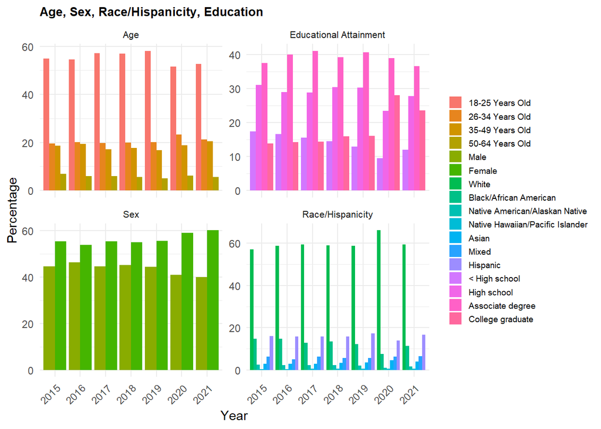

```r
library(ggplot2)

# Assign descriptive labels to each categorical variable
combined_nsduh_svhbd <- combined_nsduh_svhb |>
  mutate(
    CATAG6 = factor(
      CATAG6,
      levels = 2:5,
      labels = c(
        "18-25 Years Old",
        "26-34 Years Old",
        "35-49 Years Old",
        "50-64 Years Old"
      )
    ),
    IRSEX = factor(IRSEX, levels = 1:2, labels = c("Male", "Female")),
    NEWRACE2 = factor(
      NEWRACE2,
      levels = 1:7,
      labels = c(
        "White",
        "Black/African American",
        "Native American/Alaskan Native",
        "Native Hawaiian/Pacific Islander",
        "Asian",
        "Mixed",
        "Hispanic"
      )
    ),
    EDUHIGHCAT = factor(
      EDUHIGHCAT,
      levels = 1:4,
      labels = c(
        "< High school",
        "High school",
        "Associate degree",
        "College graduate"
      )
    ),
    IRWRKSTAT18 = factor(
      IRWRKSTAT18,
      levels = 1:4,
      labels = c(
        "Full-time",
        "Part-time",
        "Unemployed",
        "Others"
      )
    ),
    COUTYP4 = factor(
      COUTYP4,
      levels = 1:3,
      labels = c("Large Metro", "Small Metro", "Nonmetro")
    ),
    IRINSUR4 = factor(IRINSUR4, levels = 1:2, labels = c("Yes", "No")),
    IRFAMIN3 = factor(
      IRFAMIN3,
      levels = 1:7,
      labels = c(
        "< $10,000",
        "$10,000 - $19,999",
        "$20,000 - $29,999",
        "$30,000 - $39,999",
        "$40,000 - $49,999",
        "$50,000 - $74,999",
        "$75,000 or more"
      )
    ),
    IRPINC3 = factor(
      IRPINC3,
      levels = 1:7,
      labels = c(
        "< $10,000",
        "$10,000 - $19,999",
        "$20,000 - $29,999",
        "$30,000 - $39,999",
        "$40,000 - $49,999",
        "$50,000 - $74,999",
        "> $75,000"
      )
    ),
    IRMARIT = factor(
      IRMARIT,
      levels = 1:4,
      labels = c(
        "Married",
        "Widowed",
        "Divorced/Separated",
        "Never Been Married"
      )
    ),
    HB_DRINKING = factor(HB_DRINKING, levels = 0:1, labels = c("No", "Yes")),
    ILLYR = factor(ILLYR, levels = 0:1, labels = c("No", "Yes")),
    IRPYUD5ALC = factor(IRPYUD5ALC, levels = 0:1, labels = c("No", "Yes")),
    UD5ILLANY = factor(UD5ILLANY, levels = 0:1, labels = c("No", "Yes")),
    IRAMDEYR = factor(IRAMDEYR, levels = 0:1, labels = c("No", "Yes")),
    MICATPY = factor(
      MICATPY,
      levels = 0:3,
      labels = c("No", "Mild", "Moderate", "Serious")
    )
  )

# Define variable labels
variable_labels <- c(
  CATAG6 = "Age",
  IRSEX = "Sex",
  NEWRACE2 = "Race/Hispanicity",
  EDUHIGHCAT = "Educational Attainment",
  IRWRKSTAT18 = "Employment Status",
  COUTYP4 = "Rurality",
  IRINSUR4 = "Health Insurance",
  IRFAMIN3 = "Family Income",
  IRPINC3 = "Personal Income",
  IRMARIT = "Marital Status",
  HB_DRINKING = "Heavy/Binge Drinking Habit",
  ILLYR = "Illicit Drug Use",
  IRPYUD5ALC = "Alcohol Use Disorder",
  UD5ILLANY = "Drug Use Disorder",
  IRAMDEYR = "Major Depressive Episode",
  MICATPY = "Presence/Severity of Mental Illness"
)

# Pivot data from wide to long
data_long <- combined_nsduh_svhbd |>
  select(
    YEAR,
    CATAG6,
    IRSEX,
    NEWRACE2,
    EDUHIGHCAT,
    IRWRKSTAT18,
    COUTYP4,
    IRINSUR4,
    IRFAMIN3,
    IRPINC3,
    IRMARIT,
    HB_DRINKING,
    ILLYR,
    IRPYUD5ALC,
    UD5ILLANY,
    IRAMDEYR,
    MICATPY
  ) |>
  pivot_longer(
    cols = -YEAR,
    names_to = "Variable",
    values_to = "Value"
  )

# Summarize counts and percentages
summary_data <- data_long |>
  group_by(YEAR, Variable, Value) |>
  tally() |>
  group_by(YEAR, Variable) |>
  mutate(Percentage = n / sum(n) * 100) |>
  ungroup()

# Divide variables into four groups
vars_group1 <- c("CATAG6", "IRSEX", "NEWRACE2", "EDUHIGHCAT")
vars_group2 <- c("IRWRKSTAT18", "COUTYP4", "IRINSUR4", "IRFAMIN3")
vars_group3 <- c("IRPINC3", "IRMARIT", "HB_DRINKING", "ILLYR")
vars_group4 <- c("IRPYUD5ALC", "UD5ILLANY", "IRAMDEYR", "MICATPY")

# Create a custom plotting function
plot_group <- function(var_list, title) {
  data_subset <- summary_data |>
    filter(Variable %in% var_list)

  ggplot(data_subset, aes(x = factor(YEAR), y = Percentage, fill = Value)) +
    geom_bar(stat = "identity", position = position_dodge()) +
    facet_wrap(~ Variable, labeller = as_labeller(variable_labels), scales = "free_y") +
    labs(
      x = "Year",
      y = "Percentage",
      title = title
    ) +
    theme_minimal() +
    theme(
      axis.text.x = element_text(angle = 45, hjust = 1),
      legend.title = element_blank(),
      legend.text = element_text(size = 7),
      legend.key.size = unit(0.4, "cm"),
      legend.spacing.x = unit(0.1, "cm"),
      strip.text = element_text(size = 8),
      plot.title = element_text(size = 10, face = "bold")
    )
}

# Generate the four separate plots
plot1 <- plot_group(vars_group1, "Age, Sex, Race/Hispanicity, Education")
plot2 <- plot_group(vars_group2, "Employment, Rurality, Health Insurance, Family Income")
plot3 <- plot_group(vars_group3, "Personal Income, Marital Status, Heavy/Binge Drinking, Illicit Drug Use")
plot4 <- plot_group(vars_group4, "Alcohol Use Disorder, Drug Use Disorder, Major Depression, Mental Illness Severity")

# Display the plots
plot1
```

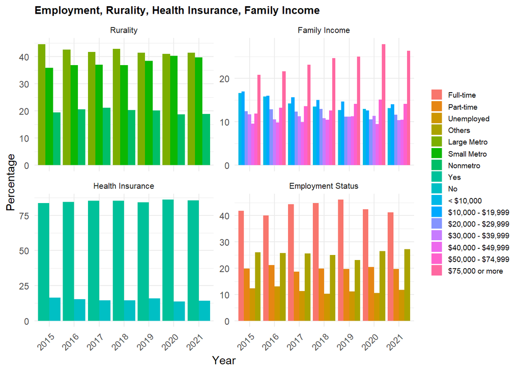

```r
plot2
```

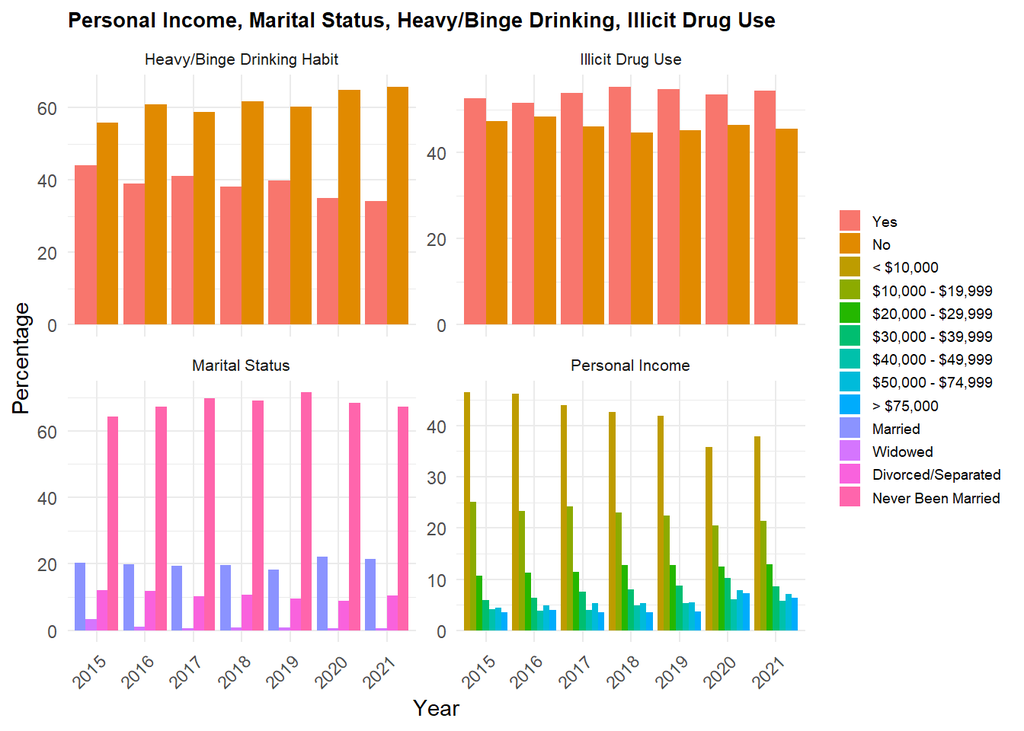

```r
plot3
```

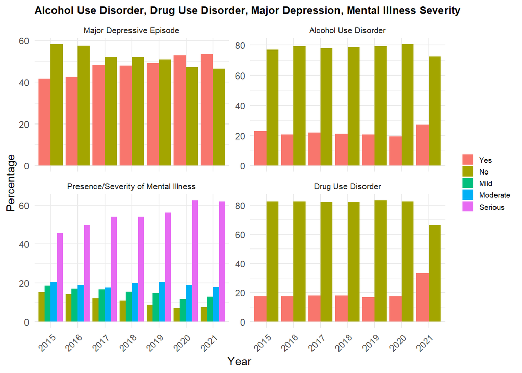

```r
plot4
```

Graphs of prevalence of SIVB, SI and VB

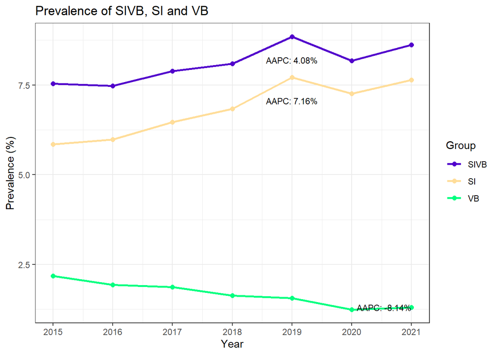

```r
#---------------------------------------------------------------
# Calculate prevalence for SIVB
prevalence_sivbc <- combined_nsduh_sv |>
  group_by(YEAR) |>
  summarize(
    total_number = n(),
    sivb_occurrences = sum(SI_VB == 1, na.rm = TRUE),
    Prevalence_sivbc = (sivb_occurrences / total_number) * 100
  ) |>
  select(Year = YEAR, Prevalence_sivbc)

#---------------------------------------------------------------
# Calculate prevalence for SI
prevalence_sic <- combined_nsduh_si |>
  group_by(YEAR) |>
  summarize(
    total_number = n(),
    si_occurrences = sum(SI == 1, na.rm = TRUE),
    Prevalence_sic = (si_occurrences / total_number) * 100
  ) |>
  select(Year = YEAR, Prevalence_sic)

#---------------------------------------------------------------
# Calculate prevalence for VB
prevalence_vbc <- combined_nsduh_vb |>
  group_by(YEAR) |>
  summarize(
    total_number = n(),
    vb_occurrences = sum(VB == 1, na.rm = TRUE),
    Prevalence_vbc = (vb_occurrences / total_number) * 100
  ) |>
  select(Year = YEAR, Prevalence_vbc)

#---------------------------------------------------------------
# Define the order of groups
group_levels <- c("SIVB", "SI", "VB")

# Prepare each dataset
prevalence_sivbc <- prevalence_sivbc |>
  rename(Prevalence = Prevalence_sivbc) |>
  mutate(Group = factor("SIVB", levels = group_levels))

prevalence_sic <- prevalence_sic |>
  rename(Prevalence = Prevalence_sic) |>
  mutate(Group = factor("SI", levels = group_levels))

prevalence_vbc <- prevalence_vbc |>
  rename(Prevalence = Prevalence_vbc) |>
  mutate(Group = factor("VB", levels = group_levels))

# Combine all datasets
prevalence_all <- bind_rows(prevalence_sivbc, prevalence_sic, prevalence_vbc)

#---------------------------------------------------------------
# Define a function to calculate the Average Annual Percentage Change (AAPC)
calculate_aapc <- function(data, group_name, start_year, end_year) {
  group_data <- data |> filter(Group == group_name)
  start_value <- group_data |> filter(Year == start_year) |> pull(Prevalence)
  end_value <- group_data |> filter(Year == end_year) |> pull(Prevalence)
  years <- end_year - start_year
  aapc <- ((end_value / start_value)^(1 / years) - 1) * 100
  return(aapc)
}

# Calculate AAPC for SIVB and SI from 2015 to 2019
sivb_aapc <- calculate_aapc(prevalence_all, "SIVB", 2015, 2019)
si_aapc   <- calculate_aapc(prevalence_all, "SI",   2015, 2019)

# Calculate AAPC for VB from 2015 to 2021
vb_aapc   <- calculate_aapc(prevalence_all, "VB",   2015, 2021)

# Create annotations
annotations <- data.frame(
  Year = c(2019, 2019, 2021),
  Prevalence = c(
    prevalence_all |> filter(Group == "SIVB" & Year == 2019) |> pull(Prevalence),
    prevalence_all |> filter(Group == "SI"   & Year == 2019) |> pull(Prevalence),
    prevalence_all |> filter(Group == "VB"   & Year == 2021) |> pull(Prevalence)
  ),
  Group = factor(c("SIVB", "SI", "VB"), levels = group_levels),
  AAPC = c(sivb_aapc, si_aapc, vb_aapc),
  hjust = c(0.5, 0.5, 1),
  vjust = c(4.0, 4.0, 0.5)
)

#---------------------------------------------------------------
# Create the combined line graph
ggplot(prevalence_all, aes(x = Year, y = Prevalence, color = Group)) +
  geom_line(linewidth = 1) +
  geom_point(size = 2) +
  scale_color_manual(values = c("SIVB" = '#5200cc', "SI" = '#ffdd99', "VB" = '#00ff80')) +
  scale_x_continuous(breaks = 2015:2021) +
  labs(
    title = "Prevalence of SIVB, SI and VB",
    x = "Year",
    y = "Prevalence (%)",
    color = "Group"
  ) +
  theme_bw() +
  theme(
    legend.position = "right",
    strip.text = element_text(face = "bold", size = 12)
  ) +
  geom_text(
    data = annotations,
    aes(
      x = Year,
      y = Prevalence,
      label = paste0("AAPC: ", round(AAPC, 2), "%"),
      hjust = hjust,
      vjust = vjust
    ),
    color = "black", # Set annotation text color to black
    size = 3,
    inherit.aes = FALSE
  )
```

Then, calculation of prevelance of utilization of Mental Health Services (MHS) including outpatient and inpatient services are conducted and corresponding graphs are plotted.

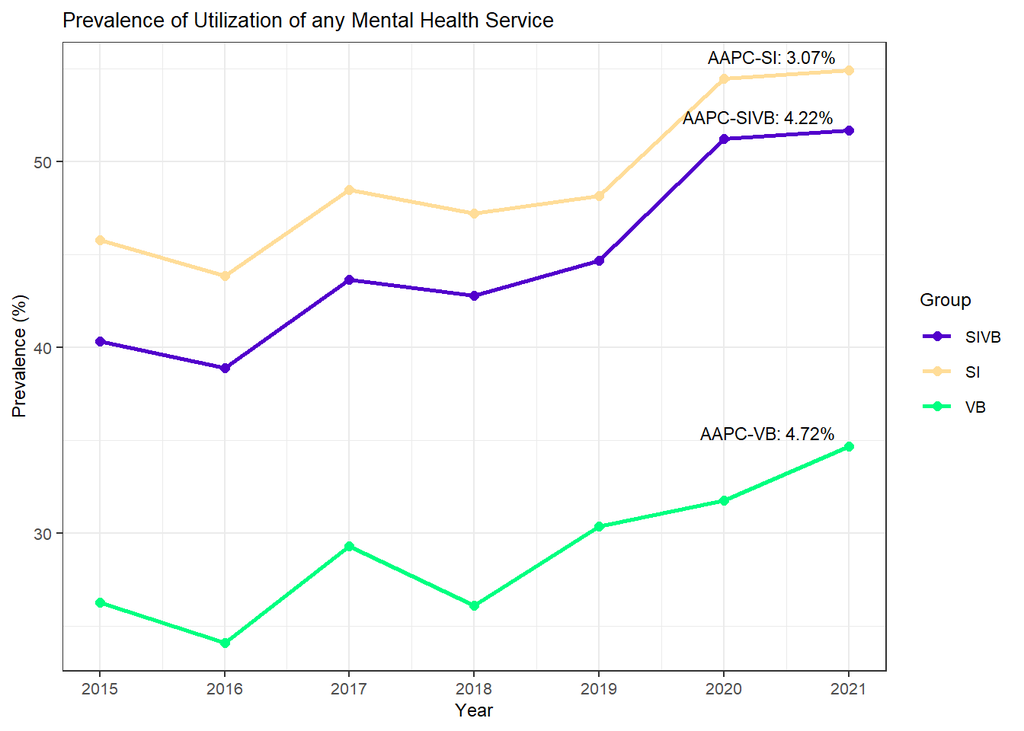

```r
# Calculate the prevalence of "AMHTXYR4" (Having any type of Mental Health Service) for "SIVB"
prevalence_MHS_sivb <- combined_nsduh_svhb |>
  filter(SI_VB == 1) |>
  group_by(YEAR) |>
  summarize(
    total_number = n(),
    AMHTXYR4_occurrences = sum(AMHTXYR4 == 1, na.rm = TRUE),
    prevalence_MHS_sivb = (AMHTXYR4_occurrences / total_number) * 100
  ) |>
  select(Year = YEAR, prevalence_MHS_sivb)

# Calculate the prevalence of "AMHTXYR4" for "SI"
prevalence_MHS_si <- combined_nsduh_svhb |>
  filter(SI == 1) |>
  group_by(YEAR) |>
  summarize(
    total_number = n(),
    AMHTXYR4_occurrences = sum(AMHTXYR4 == 1, na.rm = TRUE),
    prevalence_MHS_si = (AMHTXYR4_occurrences / total_number) * 100
  ) |>
  select(Year = YEAR, prevalence_MHS_si)

# Calculate the prevalence of "AMHTXYR4" for "VB"
prevalence_MHS_vb <- combined_nsduh_svhb |>
  filter(VB == 1) |>
  group_by(YEAR) |>
  summarize(
    total_number = n(),
    AMHTXYR4_occurrences = sum(AMHTXYR4 == 1, na.rm = TRUE),
    prevalence_MHS_vb = (AMHTXYR4_occurrences / total_number) * 100
  ) |>
  select(Year = YEAR, prevalence_MHS_vb)

# Prepare each dataset
prevalence_MHS_sivb <- prevalence_MHS_sivb |>
  rename(Prevalence = prevalence_MHS_sivb) |>
  mutate(Group = 'SIVB', Service = 'Getting MH treatment')

prevalence_MHS_si <- prevalence_MHS_si |>
  rename(Prevalence = prevalence_MHS_si) |>
  mutate(Group = 'SI', Service = 'Getting MH treatment')

prevalence_MHS_vb <- prevalence_MHS_vb |>
  rename(Prevalence = prevalence_MHS_vb) |>
  mutate(Group = 'VB', Service = 'Getting MH treatment')

# Combine all datasets into one dataframe
prevalence_all <- bind_rows(
  prevalence_MHS_sivb,
  prevalence_MHS_si,
  prevalence_MHS_vb
)

# Arrange order
prevalence_all$Group <- factor(prevalence_all$Group, levels = c('SIVB', 'SI', 'VB'))

# Ensure 'Year' is numeric
prevalence_all$Year <- as.numeric(prevalence_all$Year)


# Calculate AAPC for each group from 2015 to 2021
sivb_aapc <- calculate_aapc(prevalence_all, "SIVB", 2015, 2021)
si_aapc <- calculate_aapc(prevalence_all, "SI", 2015, 2021)
vb_aapc <- calculate_aapc(prevalence_all, "VB", 2015, 2021)

# Create annotations
annotations <- data.frame(
  Year = c(2021, 2021, 2021),
  Prevalence = c(
    prevalence_all |>
      filter(Group == "SIVB", Year == 2021) |>
      pull(Prevalence),
    prevalence_all |>
      filter(Group == "SI", Year == 2021) |>
      pull(Prevalence),
    prevalence_all |>
      filter(Group == "VB", Year == 2021) |>
      pull(Prevalence)
  ),
  Group = factor(c("SIVB", "SI", "VB"), levels = c('SIVB', 'SI', 'VB')),
  AAPC = c(sivb_aapc, si_aapc, vb_aapc),
  hjust = c(1.1, 1.1, 1.1),  # Adjust horizontal position
  vjust = c(-0.5, -0.5, -0.5)  # Adjust vertical position
)

# Handle NA AAPC values
annotations <- annotations |>
  mutate(
    AAPC_Label = ifelse(
      is.na(AAPC),
      paste0("AAPC-", Group, ": NA"),
      paste0("AAPC-", Group, ": ", round(AAPC, 2), "%")
    )
  )

# Reduce font size and labels
custom_theme <- theme(
  strip.text = element_text(face = 'bold', size = 10),
  strip.background = element_rect(linewidth = 0.5),
  legend.text = element_text(size = 8),
  legend.title = element_text(size = 9),
  axis.text = element_text(size = 8),
  axis.title = element_text(size = 9),
  plot.title = element_text(size = 10)
)

# Create the line graph with annotations
ggplot(prevalence_all, aes(x = Year, y = Prevalence, group = Group)) +
  geom_line(aes(color = Group), linewidth = 1) +
  geom_point(aes(color = Group), size = 2) +
  scale_color_manual(
    values = c(
      'SIVB' = '#5200cc',
      'SI' = '#ffdd99',
      'VB' = '#00ff80'
    )
  ) +
  scale_x_continuous(breaks = 2015:2021) +
  labs(
    title = 'Prevalence of Utilization of any Mental Health Service',
    x = 'Year',
    y = 'Prevalence (%)',
    color = 'Group'
  ) +
  theme_bw() +
  custom_theme +
  geom_text(
    data = annotations,
    aes(
      x = Year,
      y = Prevalence,
      label = AAPC_Label
    ),
    color = "black",  # Set the annotation color to black
    size = 3,
    hjust = annotations$hjust,
    vjust = annotations$vjust,
    show.legend = FALSE
  )
```

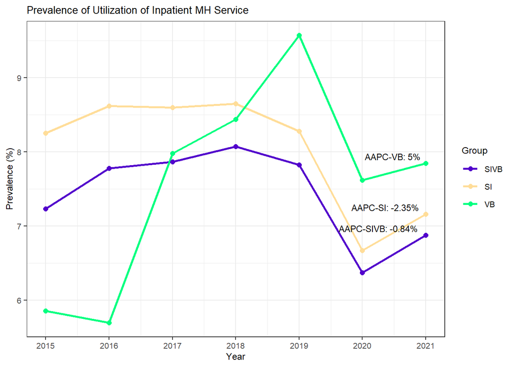

```r
#-------------------------------------------------------------------------------


# Calculate the prevalence of "AMHINP2" (Inpatient Mental Health Service) for "SIVB"
prevalence_MHS_sivb <- combined_nsduh_svhb |>
  filter(SI_VB == 1) |>
  group_by(YEAR) |>
  summarize(
    total_number = n(),
    AMHINP2_occurrences = sum(AMHINP2 == 1, na.rm = TRUE),
    prevalence_MHS_sivb = (AMHINP2_occurrences / total_number) * 100
  ) |>
  select(Year = YEAR, prevalence_MHS_sivb)

# Calculate the prevalence of "AMHINP2" for "SI"
prevalence_MHS_si <- combined_nsduh_svhb |>
  filter(SI == 1) |>
  group_by(YEAR) |>
  summarize(
    total_number = n(),
    AMHINP2_occurrences = sum(AMHINP2 == 1, na.rm = TRUE),
    prevalence_MHS_si = (AMHINP2_occurrences / total_number) * 100
  ) |>
  select(Year = YEAR, prevalence_MHS_si)

# Calculate the prevalence of "AMHINP2" for "VB"
prevalence_MHS_vb <- combined_nsduh_svhb |>
  filter(VB == 1) |>
  group_by(YEAR) |>
  summarize(
    total_number = n(),
    AMHINP2_occurrences = sum(AMHINP2 == 1, na.rm = TRUE),
    prevalence_MHS_vb = (AMHINP2_occurrences / total_number) * 100
  ) |>
  select(Year = YEAR, prevalence_MHS_vb)

# Prepare each dataset
prevalence_MHS_sivb <- prevalence_MHS_sivb |>
  rename(Prevalence = prevalence_MHS_sivb) |>
  mutate(Group = 'SIVB', Service = 'Inpatient MH Service')

prevalence_MHS_si <- prevalence_MHS_si |>
  rename(Prevalence = prevalence_MHS_si) |>
  mutate(Group = 'SI', Service = 'Inpatient MH Service')

prevalence_MHS_vb <- prevalence_MHS_vb |>
  rename(Prevalence = prevalence_MHS_vb) |>
  mutate(Group = 'VB', Service = 'Inpatient MH Service')

# Combine all datasets into one dataframe
prevalence_all <- bind_rows(
  prevalence_MHS_sivb,
  prevalence_MHS_si,
  prevalence_MHS_vb
)

# Arrange order
prevalence_all$Group <- factor(prevalence_all$Group, levels = c('SIVB', 'SI', 'VB'))

# Ensure 'Year' is numeric
prevalence_all$Year <- as.numeric(prevalence_all$Year)


# Calculate AAPC for each group from 2015 to 2021
sivb_aapc <- calculate_aapc(prevalence_all, "SIVB", 2015, 2021)
si_aapc <- calculate_aapc(prevalence_all, "SI", 2015, 2021)
vb_aapc <- calculate_aapc(prevalence_all, "VB", 2015, 2021)

# Create annotations
annotations <- data.frame(
  Year = c(2021, 2021, 2021),
  Prevalence = c(
    prevalence_all |>
      filter(Group == "SIVB", Year == 2021) |>
      pull(Prevalence),
    prevalence_all |>
      filter(Group == "SI", Year == 2021) |>
      pull(Prevalence),
    prevalence_all |>
      filter(Group == "VB", Year == 2021) |>
      pull(Prevalence)
  ),
  Group = factor(c("SIVB", "SI", "VB"), levels = c('SIVB', 'SI', 'VB')),
  AAPC = c(sivb_aapc, si_aapc, vb_aapc),
  hjust = c(1.1, 1.1, 1.1),  # Adjust horizontal position
  vjust = c(-0.5, -0.5, -0.5)  # Adjust vertical position
)

# Handle NA AAPC values
annotations <- annotations |>
  mutate(
    AAPC_Label = ifelse(
      is.na(AAPC),
      paste0("AAPC-", Group, ": NA"),
      paste0("AAPC-", Group, ": ", round(AAPC, 2), "%")
    )
  )

# Reduce font size and labels
custom_theme <- theme(
  strip.text = element_text(face = 'bold', size = 10),
  strip.background = element_rect(linewidth = 0.5),
  legend.text = element_text(size = 8),
  legend.title = element_text(size = 9),
  axis.text = element_text(size = 8),
  axis.title = element_text(size = 9),
  plot.title = element_text(size = 10)
)

# Create the line graph with annotations
ggplot(prevalence_all, aes(x = Year, y = Prevalence, group = Group)) +
  geom_line(aes(color = Group), linewidth = 1) +
  geom_point(aes(color = Group), size = 2) +
  scale_color_manual(
    values = c(
      'SIVB' = '#5200cc',
      'SI' = '#ffdd99',
      'VB' = '#00ff80'
    )
  ) +
  scale_x_continuous(breaks = 2015:2021) +
  labs(
    title = 'Prevalence of Utilization of Inpatient MH Service',
    x = 'Year',
    y = 'Prevalence (%)',
    color = 'Group'
  ) +
  theme_bw() +
  custom_theme +
  geom_text(
    data = annotations,
    aes(
      x = Year,
      y = Prevalence,
      label = AAPC_Label
    ),
    color = "black",  # Set the annotation color to black
    size = 3,
    hjust = annotations$hjust,
    vjust = annotations$vjust,
    show.legend = FALSE
  )
```

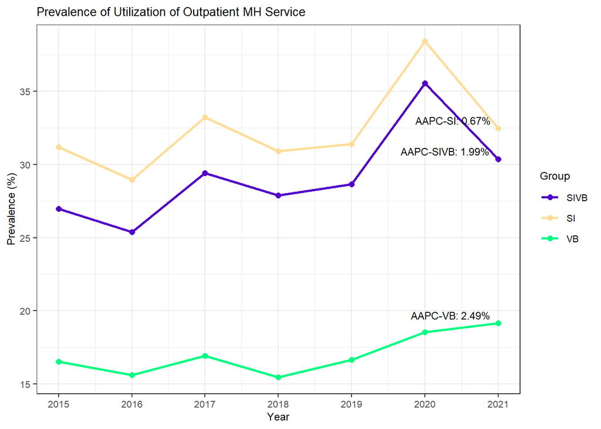

```r
#--------------------------------------------------------------------------------



# Calculate the prevalence of "AMHOUTP4" (Outpatient Mental Health Service) for "SIVB"
prevalence_MHS_sivb <- combined_nsduh_svhb |>
  filter(SI_VB == 1) |>
  group_by(YEAR) |>
  summarize(
    total_number = n(),
    AMHOUTP4_occurrences = sum(AMHOUTP4 == 1, na.rm = TRUE),
    prevalence_MHS_sivb = (AMHOUTP4_occurrences / total_number) * 100
  ) |>
  select(Year = YEAR, prevalence_MHS_sivb)

# Calculate the prevalence of "AMHOUTP4" for "SI"
prevalence_MHS_si <- combined_nsduh_svhb |>
  filter(SI == 1) |>
  group_by(YEAR) |>
  summarize(
    total_number = n(),
    AMHOUTP4_occurrences = sum(AMHOUTP4 == 1, na.rm = TRUE),
    prevalence_MHS_si = (AMHOUTP4_occurrences / total_number) * 100
  ) |>
  select(Year = YEAR, prevalence_MHS_si)

# Calculate the prevalence of "AMHOUTP4" for "VB"
prevalence_MHS_vb <- combined_nsduh_svhb |>
  filter(VB == 1) |>
  group_by(YEAR) |>
  summarize(
    total_number = n(),
    AMHOUTP4_occurrences = sum(AMHOUTP4 == 1, na.rm = TRUE),
    prevalence_MHS_vb = (AMHOUTP4_occurrences / total_number) * 100
  ) |>
  select(Year = YEAR, prevalence_MHS_vb)

# Prepare each dataset
prevalence_MHS_sivb <- prevalence_MHS_sivb |>
  rename(Prevalence = prevalence_MHS_sivb) |>
  mutate(Group = 'SIVB', Service = 'Outpatient MH Service')

prevalence_MHS_si <- prevalence_MHS_si |>
  rename(Prevalence = prevalence_MHS_si) |>
  mutate(Group = 'SI', Service = 'Outpatient MH Service')

prevalence_MHS_vb <- prevalence_MHS_vb |>
  rename(Prevalence = prevalence_MHS_vb) |>
  mutate(Group = 'VB', Service = 'Outpatient MH Service')

# Combine all datasets into one dataframe
prevalence_all <- bind_rows(
  prevalence_MHS_sivb,
  prevalence_MHS_si,
  prevalence_MHS_vb
)

# Arrange the order
prevalence_all$Group <- factor(prevalence_all$Group, levels = c('SIVB', 'SI', 'VB'))

# Ensure 'Year' is numeric
prevalence_all$Year <- as.numeric(prevalence_all$Year)


# Calculate AAPC for each group from 2015 to 2021
sivb_aapc <- calculate_aapc(prevalence_all, "SIVB", 2015, 2021)
si_aapc <- calculate_aapc(prevalence_all, "SI", 2015, 2021)
vb_aapc <- calculate_aapc(prevalence_all, "VB", 2015, 2021)

# Create annotations
annotations <- data.frame(
  Year = c(2021, 2021, 2021),
  Prevalence = c(
    prevalence_all |>
      filter(Group == "SIVB", Year == 2021) |>
      pull(Prevalence),
    prevalence_all |>
      filter(Group == "SI", Year == 2021) |>
      pull(Prevalence),
    prevalence_all |>
      filter(Group == "VB", Year == 2021) |>
      pull(Prevalence)
  ),
  Group = factor(c("SIVB", "SI", "VB"), levels = c('SIVB', 'SI', 'VB')),
  AAPC = c(sivb_aapc, si_aapc, vb_aapc),
  hjust = c(1.1, 1.1, 1.1),  # Adjust horizontal position
  vjust = c(-0.5, -0.5, -0.5)  # Adjust vertical position
)

# Handle NA AAPC values
annotations <- annotations |>
  mutate(
    AAPC_Label = ifelse(
      is.na(AAPC),
      paste0("AAPC-", Group, ": NA"),
      paste0("AAPC-", Group, ": ", round(AAPC, 2), "%")
    )
  )

# Reduce font size and height of labels
custom_theme <- theme(
  strip.text = element_text(face = 'bold', size = 10),
  strip.background = element_rect(linewidth = 0.5),
  legend.text = element_text(size = 8),
  legend.title = element_text(size = 9),
  axis.text = element_text(size = 8),
  axis.title = element_text(size = 9),
  plot.title = element_text(size = 10)
)

# Create the line graph with annotations
ggplot(prevalence_all, aes(x = Year, y = Prevalence, group = Group)) +
  geom_line(aes(color = Group), linewidth = 1) +
  geom_point(aes(color = Group), size = 2) +
  scale_color_manual(
    values = c(
      'SIVB' = '#5200cc',
      'SI' = '#ffdd99',
      'VB' = '#00ff80'
    )
  ) +
  scale_x_continuous(breaks = 2015:2021) +
  labs(
    title = 'Prevalence of Utilization of Outpatient MH Service',
    x = 'Year',
    y = 'Prevalence (%)',
    color = 'Group'
  ) +
  theme_bw() +
  custom_theme +
  geom_text(
    data = annotations,
    aes(
      x = Year,
      y = Prevalence,
      label = AAPC_Label
    ),
    color = "black",  # Set the annotation color to black
    size = 3,
    hjust = annotations$hjust,
    vjust = annotations$vjust,
    show.legend = FALSE
  )
```

Subsequently, calculation of the prevalence of Perceived Unmet Need for Mental Health Services (MHS) for SIVB, SI,VB are conducted and the corresponding graphs are plotted.

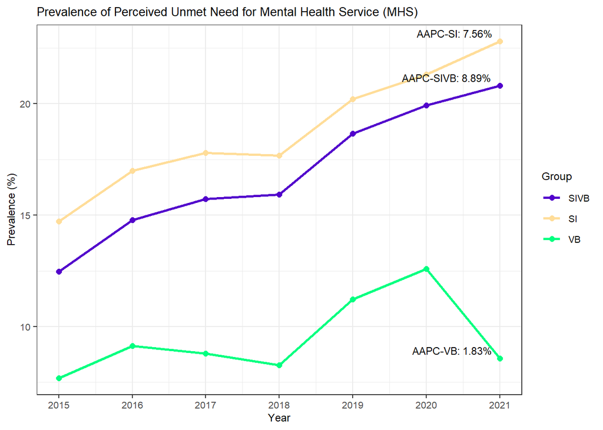

```r
# Calculate the prevalence of "AMHTXAND4" (Unmet Need for Mental Health Service (MHS)) for "SIVB"
prevalence_MHS_sivb <- combined_nsduh_svhb |>
  filter(SI_VB == 1) |>
  group_by(YEAR) |>
  summarize(
    total_number = n(),
    AMHTXAND4_occurrences = sum(AMHTXAND4 == 1, na.rm = TRUE),
    prevalence_MHS_sivb = (AMHTXAND4_occurrences / total_number) * 100
  ) |>
  select(Year = YEAR, prevalence_MHS_sivb)

# Calculate the prevalence of "AMHTXAND4" for "SI"
prevalence_MHS_si <- combined_nsduh_svhb |>
  filter(SI == 1) |>
  group_by(YEAR) |>
  summarize(
    total_number = n(),
    AMHTXAND4_occurrences = sum(AMHTXAND4 == 1, na.rm = TRUE),
    prevalence_MHS_si = (AMHTXAND4_occurrences / total_number) * 100
  ) |>
  select(Year = YEAR, prevalence_MHS_si)

# Calculate the prevalence of "AMHTXAND4" for "VB"
prevalence_MHS_vb <- combined_nsduh_svhb |>
  filter(VB == 1) |>
  group_by(YEAR) |>
  summarize(
    total_number = n(),
    AMHTXAND4_occurrences = sum(AMHTXAND4 == 1, na.rm = TRUE),
    prevalence_MHS_vb = (AMHTXAND4_occurrences / total_number) * 100
  ) |>
  select(Year = YEAR, prevalence_MHS_vb)

# Prepare each dataset
prevalence_MHS_sivb <- prevalence_MHS_sivb |>
  rename(Prevalence = prevalence_MHS_sivb) |>
  mutate(Group = 'SIVB', Service = 'Unmet Need for Mental Health Service (MHS)')

prevalence_MHS_si <- prevalence_MHS_si |>
  rename(Prevalence = prevalence_MHS_si) |>
  mutate(Group = 'SI', Service = 'Unmet Need for Mental Health Service (MHS)')

prevalence_MHS_vb <- prevalence_MHS_vb |>
  rename(Prevalence = prevalence_MHS_vb) |>
  mutate(Group = 'VB', Service = 'Unmet Need for Mental Health Service (MHS)')

# Combine all datasets into one dataframe
prevalence_all <- bind_rows(
  prevalence_MHS_sivb,
  prevalence_MHS_si,
  prevalence_MHS_vb
)

# Convert 'Group' to a factor with the desired order
prevalence_all$Group <- factor(prevalence_all$Group, levels = c('SIVB', 'SI', 'VB'))

# Ensure 'Year' is numeric
prevalence_all$Year <- as.numeric(prevalence_all$Year)


# Calculate AAPC for each group from 2015 to 2021
sivb_aapc <- calculate_aapc(prevalence_all, "SIVB", 2015, 2021)
si_aapc <- calculate_aapc(prevalence_all, "SI", 2015, 2021)
vb_aapc <- calculate_aapc(prevalence_all, "VB", 2015, 2021)

# Create annotations
annotations <- data.frame(
  Year = c(2021, 2021, 2021),
  Prevalence = c(
    prevalence_all |>
      filter(Group == "SIVB", Year == 2021) |>
      pull(Prevalence),
    prevalence_all |>
      filter(Group == "SI", Year == 2021) |>
      pull(Prevalence),
    prevalence_all |>
      filter(Group == "VB", Year == 2021) |>
      pull(Prevalence)
  ),
  Group = factor(c("SIVB", "SI", "VB"), levels = c('SIVB', 'SI', 'VB')),
  AAPC = c(sivb_aapc, si_aapc, vb_aapc),
  hjust = c(1.1, 1.1, 1.1),  # Adjust horizontal position
  vjust = c(-0.5, -0.5, -0.5)  # Adjust vertical position
)

# Handle NA AAPC values
annotations <- annotations |>
  mutate(
    AAPC_Label = ifelse(
      is.na(AAPC),
      paste0("AAPC-", Group, ": NA"),
      paste0("AAPC-", Group, ": ", round(AAPC, 2), "%")
    )
  )

# Reduce font size
custom_theme <- theme(
  strip.text = element_text(face = 'bold', size = 10),
  strip.background = element_rect(linewidth = 0.5),
  legend.text = element_text(size = 8),
  legend.title = element_text(size = 9),
  axis.text = element_text(size = 8),
  axis.title = element_text(size = 9),
  plot.title = element_text(size = 10)
)

# Create the line graph with annotations
ggplot(prevalence_all, aes(x = Year, y = Prevalence, group = Group)) +
  geom_line(aes(color = Group), linewidth = 1) +
  geom_point(aes(color = Group), size = 2) +
  scale_color_manual(
    values = c(
      'SIVB' = '#5200cc',
      'SI' = '#ffdd99',
      'VB' = '#00ff80'
    )
  ) +
  scale_x_continuous(breaks = 2015:2021) +
  labs(
    title = 'Prevalence of Perceived Unmet Need for Mental Health Service (MHS)',
    x = 'Year',
    y = 'Prevalence (%)',
    color = 'Group'
  ) +
  theme_bw() +
  custom_theme +
  geom_text(
    data = annotations,
    aes(
      x = Year,
      y = Prevalence,
      label = AAPC_Label
    ),
    color = "black",  # Set the annotation color to black
    size = 3,
    hjust = annotations$hjust,
    vjust = annotations$vjust,
    show.legend = FALSE
  )
```

Then, the plots for reasons of not seeking treatment for SIVB, SI and VB are shown.

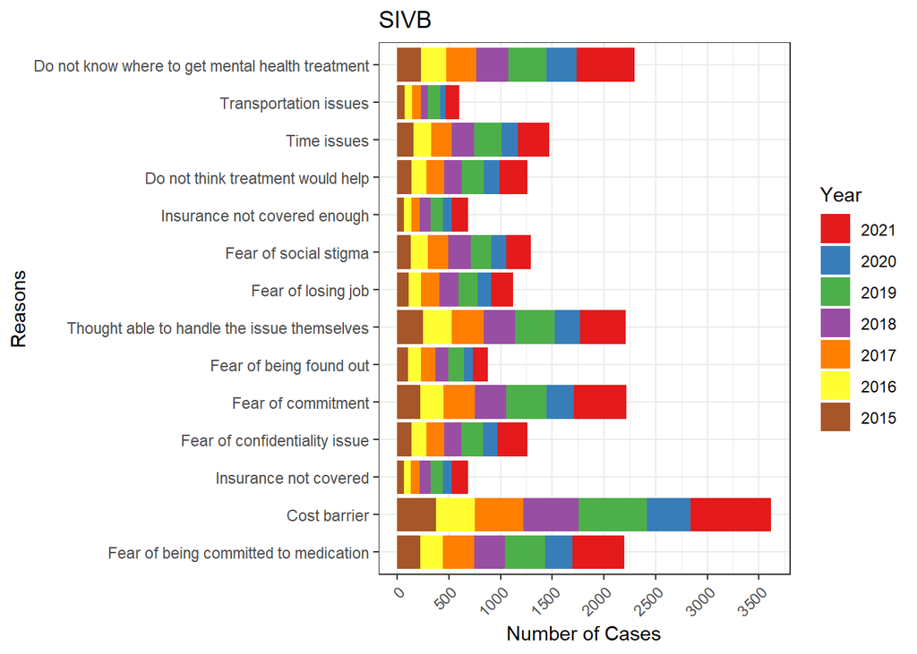

```r
library(scales)

# List of variables to test
variables_of_interest <- c(
  "MHRNCOV2", "MHRNBRS2", "MHRTRAN2", "MHRTIME2", "AUUNNCOV",
  "MHRWHER2", "MHRNOHP2", "AUUNCOST", "MHRHAND2", "AUUNCMIT",
  "MHRJOBS2", "MHRCMIT2", "MHRCFID2", "MHRFOUT2"
)

# Map of variable codes to descriptive labels
variable_labels <- c(
  MHRNCOV2 = "Insurance not covered enough",
  MHRNBRS2 = "Fear of social stigma",
  MHRTRAN2 = "Transportation issues",
  MHRTIME2 = "Time issues",
  AUUNNCOV = "Insurance not covered",
  MHRWHER2 = "Do not know where to get mental health treatment",
  MHRNOHP2 = "Do not think treatment would help",
  AUUNCOST = "Cost barrier",
  MHRHAND2 = "Thought able to handle the issue themselves",
  AUUNCMIT = "Fear of being committed to medication",
  MHRJOBS2 = "Fear of losing job",
  MHRCMIT2 = "Fear of commitment",
  MHRCFID2 = "Fear of confidentiality issue",
  MHRFOUT2 = "Fear of being found out"
)

# Filter dataset to include only SIVB and the YEAR column
data_filtered <- combined_nsduh_svhb |>
  filter(SI_VB == 1) |>
  select(YEAR, all_of(variables_of_interest))

# Convert the data to long format
data_long <- data_filtered |>
  pivot_longer(
    cols = -YEAR, # All columns except YEAR
    names_to = "Variable",
    values_to = "Count"
  )

# Count the occurrences
summary_counts <- data_long |>
  filter(Count == 1) |>
  group_by(YEAR, Variable) |>
  summarise(Count = n(), .groups = "drop")

# Reverse the order of the years within each bar
summary_counts$YEAR <- factor(summary_counts$YEAR, levels = sort(unique(summary_counts$YEAR), decreasing = TRUE))


# Create the horizontal bar chart
ggplot(summary_counts, aes(x = Variable, y = Count, fill = YEAR)) +
  geom_bar(stat = "identity", position = "stack") +
  labs(
    title = "SIVB",
    x = "Reasons",
    y = "Number of Cases",
    fill = "Year"
  ) +
  scale_fill_brewer(palette = "Set1") + # Use ColorBrewer palette
  scale_y_continuous(
    breaks = seq(0, 6000, by = 500),  # Set breaks to appear every 500 up to 6000
    labels = seq(0, 6000, by = 500)
  ) +
  scale_x_discrete(labels = variable_labels) +
  theme_bw() +
  theme(axis.text.x = element_text(angle = 45, hjust = 1)) +
  coord_flip()
```

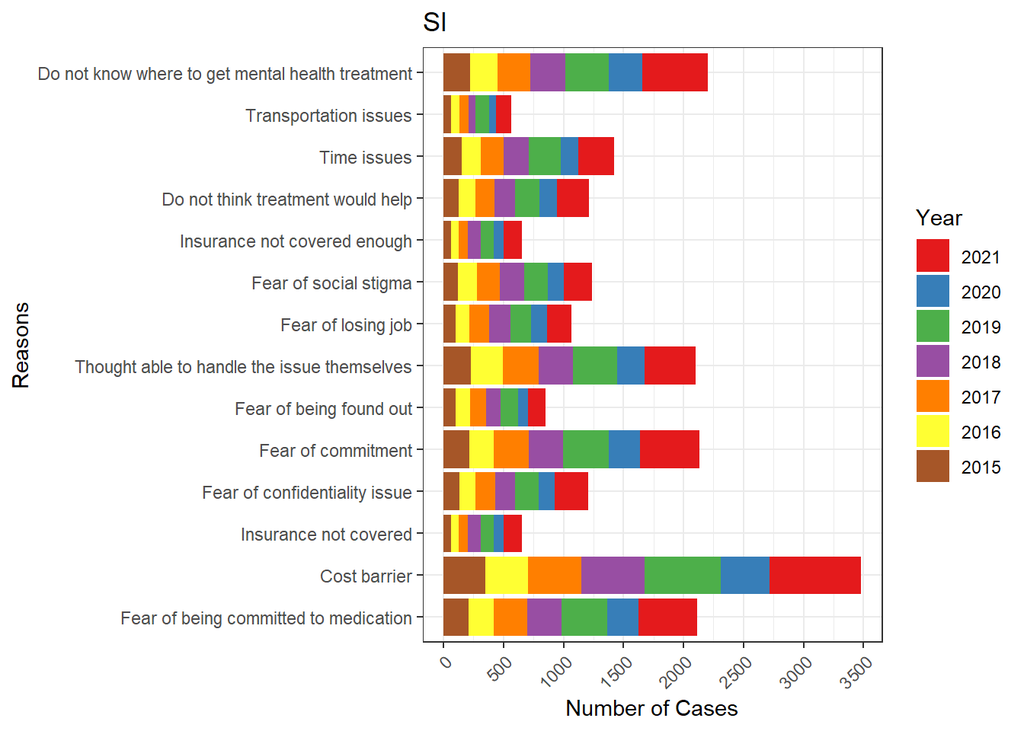

```r
#-------------------------------------------------------------------------------


# Filter dataset to include only SI and the YEAR column
data_filtered <- combined_nsduh_svhb |>
  filter(SI == 1) |>
  select(YEAR, all_of(variables_of_interest))

# Convert the data to long format
data_long <- data_filtered |>
  pivot_longer(
    cols = -YEAR, # All columns except YEAR
    names_to = "Variable",
    values_to = "Count"
  )

# Count the occurrences
summary_counts <- data_long |>
  filter(Count == 1) |>
  group_by(YEAR, Variable) |>
  summarise(Count = n(), .groups = "drop")

# Reverse the order of the years within each bar
summary_counts$YEAR <- factor(summary_counts$YEAR, levels = sort(unique(summary_counts$YEAR), decreasing = TRUE))


# Create the horizontal bar chart
ggplot(summary_counts, aes(x = Variable, y = Count, fill = YEAR)) +
  geom_bar(stat = "identity", position = "stack") +
  labs(
    title = "SI",
    x = "Reasons",
    y = "Number of Cases",
    fill = "Year"
  ) +
  scale_fill_brewer(palette = "Set1") + # Use ColorBrewer palette
  scale_y_continuous(
    breaks = seq(0, 6000, by = 500),  # Set breaks to appear every 500 up to 6000
    labels = seq(0, 6000, by = 500)
  ) +
  scale_x_discrete(labels = variable_labels) +
  theme_bw() +
  theme(axis.text.x = element_text(angle = 45, hjust = 1)) +
  coord_flip()
```

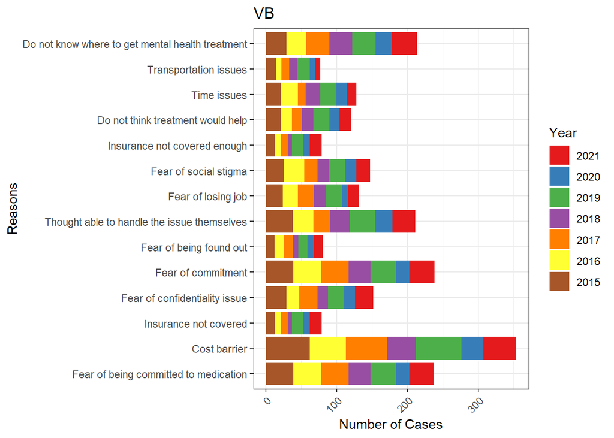

```r
#--------------------------------------------------------------------------------


# Filter dataset to include only VB
data_filtered <- combined_nsduh_svhb |>
  filter(VB == 1) |>
  select(YEAR, all_of(variables_of_interest))

# Convert the data to long format
data_long <- data_filtered |>
  pivot_longer(
    cols = -YEAR, # All columns except YEAR
    names_to = "Variable",
    values_to = "Count"
  )

# Count the occurrences
summary_counts <- data_long |>
  filter(Count == 1) |>
  group_by(YEAR, Variable) |>
  summarise(Count = n(), .groups = "drop")

# Reverse the order of the years within each bar
summary_counts$YEAR <- factor(summary_counts$YEAR, levels = sort(unique(summary_counts$YEAR), decreasing = TRUE))


# Create the horizontal bar chart
ggplot(summary_counts, aes(x = Variable, y = Count, fill = YEAR)) +
  geom_bar(stat = "identity", position = "stack") +
  labs(
    title = "VB",
    x = "Reasons",
    y = "Number of Cases",
    fill = "Year"
  ) +
  scale_fill_brewer(palette = "Set1") + # Use ColorBrewer palette
  scale_y_continuous(
    breaks = seq(0, 600, by = 100),
    labels = seq(0, 600, by = 100)
  ) +
  scale_x_discrete(labels = variable_labels) +
  theme_bw() +
  theme(axis.text.x = element_text(angle = 45, hjust = 1)) +
  coord_flip()
```

Next, Multivariable Logistics Regression Analysis is performed.

```r
library(car)

#SIVB as outcome
categorical_vars <- c("YEAR", "CATAG6", "IRSEX", "NEWRACE2", "EDUHIGHCAT", "IRWRKSTAT18", "COUTYP4", "IRINSUR4", "IRFAMIN3", "IRPINC3", "IRMARIT", "HB_DRINKING", "ILLYR", "IRPYUD5ALC", "UD5ILLANY", "IRAMDEYR", "MICATPY")

combined_nsduh_sv <- combined_nsduh_sv |>
  mutate(across(all_of(categorical_vars), as.factor))


# Fit the logistic regression model
sivb_glm <- glm(SI_VB ~ YEAR + CATAG6 + IRSEX + NEWRACE2 + EDUHIGHCAT + IRWRKSTAT18 + COUTYP4 + IRINSUR4 + IRFAMIN3 + IRPINC3 + IRMARIT + HB_DRINKING + ILLYR + IRPYUD5ALC + UD5ILLANY + IRAMDEYR + MICATPY,
                data = combined_nsduh_sv,
                family = "binomial")

# Obtain the ANOVA table
anova_results <- Anova(sivb_glm, type = "III", test = "Wald")

# Convert to data frame for easy manipulation
anova_df <- as.data.frame(anova_results)
p_values <- anova_df[["Pr(>Chisq)"]]

# Variable names come from the row names of the anova_df
variables <- rownames(anova_df)

# Remove the intercept row
keep_rows <- variables != "(Intercept)" & !is.na(p_values)
variables <- variables[keep_rows]
p_values <- p_values[keep_rows]

# Apply Bonferroni correction across these variables
adjusted_p <- p.adjust(p_values, method = "bonferroni")

# Determine Bonferroni threshold
num_vars <- length(p_values)
bonferroni_threshold <- 0.05 / num_vars

# Create a data frame with results
results_anova <- data.frame(
  Variable = variables,
  Original_p = p_values,
  Bonferroni_p = adjusted_p,
  Bonferroni_Threshold = bonferroni_threshold,
  stringsAsFactors = FALSE
)

# Filter to keep only variables that are significant after Bonferroni correction
results_significant <- subset(results_anova, Bonferroni_p < Bonferroni_Threshold)

# Print the full results
print(results_anova)
```

```
      Variable    Original_p  Bonferroni_p Bonferroni_Threshold
1         YEAR  1.096934e-23  1.864787e-22          0.002941176
2       CATAG6  0.000000e+00  0.000000e+00          0.002941176
3        IRSEX 6.201707e-143 1.054290e-141          0.002941176
4     NEWRACE2  1.333118e-85  2.266301e-84          0.002941176
5   EDUHIGHCAT  1.372368e-93  2.333025e-92          0.002941176
6  IRWRKSTAT18  4.431190e-39  7.533023e-38          0.002941176
7      COUTYP4  1.551901e-02  2.638232e-01          0.002941176
8     IRINSUR4  2.715589e-05  4.616502e-04          0.002941176
9     IRFAMIN3  8.907315e-01  1.000000e+00          0.002941176
10     IRPINC3  1.019684e-07  1.733464e-06          0.002941176
11     IRMARIT  1.012361e-11  1.721013e-10          0.002941176
12 HB_DRINKING  1.800479e-02  3.060814e-01          0.002941176
13       ILLYR  1.478934e-47  2.514187e-46          0.002941176
14  IRPYUD5ALC  3.582561e-43  6.090353e-42          0.002941176
15   UD5ILLANY  2.841017e-13  4.829729e-12          0.002941176
16    IRAMDEYR  0.000000e+00  0.000000e+00          0.002941176
17     MICATPY  0.000000e+00  0.000000e+00          0.002941176
```

```r
# Print only the variables that remain significant after Bonferroni correction
print(results_significant)
```

```
      Variable    Original_p  Bonferroni_p Bonferroni_Threshold
1         YEAR  1.096934e-23  1.864787e-22          0.002941176
2       CATAG6  0.000000e+00  0.000000e+00          0.002941176
3        IRSEX 6.201707e-143 1.054290e-141          0.002941176
4     NEWRACE2  1.333118e-85  2.266301e-84          0.002941176
5   EDUHIGHCAT  1.372368e-93  2.333025e-92          0.002941176
6  IRWRKSTAT18  4.431190e-39  7.533023e-38          0.002941176
8     IRINSUR4  2.715589e-05  4.616502e-04          0.002941176
10     IRPINC3  1.019684e-07  1.733464e-06          0.002941176
11     IRMARIT  1.012361e-11  1.721013e-10          0.002941176
13       ILLYR  1.478934e-47  2.514187e-46          0.002941176
14  IRPYUD5ALC  3.582561e-43  6.090353e-42          0.002941176
15   UD5ILLANY  2.841017e-13  4.829729e-12          0.002941176
16    IRAMDEYR  0.000000e+00  0.000000e+00          0.002941176
17     MICATPY  0.000000e+00  0.000000e+00          0.002941176
```

```r
#-------------------------------------------------------------------------------



# Fit the logistic regression model after Bonferroni correction, removing COUNTYP4, IRFAMIN3, HB_DRINKING

#SIVB as outcome
categorical_vars <- c("YEAR", "CATAG6", "IRSEX", "NEWRACE2", "EDUHIGHCAT", "IRWRKSTAT18", "IRINSUR4", "IRPINC3", "IRMARIT", "ILLYR", "IRPYUD5ALC", "UD5ILLANY", "IRAMDEYR", "MICATPY")

combined_nsduh_sv <- combined_nsduh_sv |>
  mutate(across(all_of(categorical_vars), as.factor))

sivb_glmb <- glm(SI_VB ~ YEAR + CATAG6 + IRSEX + NEWRACE2 + EDUHIGHCAT + IRWRKSTAT18 + IRINSUR4 + IRPINC3 + IRMARIT + ILLYR + IRPYUD5ALC + UD5ILLANY + IRAMDEYR + MICATPY, data = combined_nsduh_sv, family = "binomial")


# Calculate Odds Ratios (OR) and Confidence Intervals (CI)
odds_ratios <- exp(cbind(
  OR = coef(sivb_glmb),
  CI_Lower = confint(sivb_glmb)[, 1],
  CI_Upper = confint(sivb_glmb)[, 2]
))

# Convert to data frame and assign column names
odds_ratios_df <- odds_ratios |>
  as.data.frame() |>
  rename(OR = OR, CI_Lower = CI_Lower, CI_Upper = CI_Upper)

# Round all numerical columns to 4 decimal places
odds_ratios_df <- round(odds_ratios_df, 4)

# View all the odds ratios
print(odds_ratios_df)
```

```
                   OR CI_Lower CI_Upper
(Intercept)    0.0302   0.0273   0.0335
YEAR2016       0.9151   0.8529   0.9819
YEAR2017       0.8644   0.8060   0.9270
YEAR2018       0.8816   0.8222   0.9451
YEAR2019       0.8188   0.7644   0.8770
YEAR2020       0.8249   0.7615   0.8935
YEAR2021       0.6952   0.6492   0.7445
CATAG63        0.3878   0.3671   0.4096
CATAG64        0.3126   0.2937   0.3327
CATAG65        0.3269   0.2993   0.3567
IRSEX2         0.5896   0.5660   0.6140
NEWRACE22      1.7289   1.6285   1.8352
NEWRACE23      1.9273   1.6726   2.2161
NEWRACE24      1.5590   1.1927   2.0178
NEWRACE25      1.2118   1.0932   1.3415
NEWRACE26      1.3919   1.2756   1.5178
NEWRACE27      1.1460   1.0854   1.2098
EDUHIGHCAT2    0.7696   0.7225   0.8199
EDUHIGHCAT3    0.6286   0.5906   0.6692
EDUHIGHCAT4    0.4650   0.4315   0.5012
IRWRKSTAT182   0.9164   0.8657   0.9700
IRWRKSTAT183   1.4044   1.3089   1.5066
IRWRKSTAT184   0.8690   0.8218   0.9188
IRINSUR42      1.1296   1.0687   1.1937
IRPINC32       0.8849   0.8394   0.9327
IRPINC33       0.8278   0.7735   0.8857
IRPINC34       0.8361   0.7720   0.9052
IRPINC35       0.8068   0.7331   0.8872
IRPINC36       0.8620   0.7857   0.9453
IRPINC37       0.9462   0.8534   1.0484
IRMARIT2       1.0948   0.9150   1.3053
IRMARIT3       1.1305   1.0531   1.2134
IRMARIT4       1.2242   1.1598   1.2923
ILLYR1         1.3963   1.3373   1.4578
IRPYUD5ALC1    1.5100   1.4337   1.5902
UD5ILLANY1     1.2520   1.1780   1.3305
IRAMDEYR1      0.2444   0.2297   0.2599
MICATPY1      12.9088  12.1822  13.6809
MICATPY2      49.1460  46.1617  52.3361
MICATPY3     761.5762 700.9927 827.9134
```

After Multivariable Logistics Regression with Bonferoni correction, 13 variables are significant which will be included in the final model- Age category, Sex, Race/ethnicity, Education Attainment, Work status aged 18+, Health insurance, Personal income, Marital status, Illicit drug use, alcohol disorder, Drug Disorder, Major depressive episode , Mental illness

Then, examination of multicollinearity between the variables is performed.

```r
library(car)

# Calculate Variance Inflation Factors (VIF) for the model
vif_values <- vif(sivb_glmb)

# Convert VIF results to a data frame for easier interpretation
vif_df <- as.data.frame(vif_values)

# Round the values for neat display
vif_df <- round(vif_df, 3)

# Print the VIF results
print(vif_df)
```

```
             GVIF Df GVIF^(1/(2*Df))
YEAR        1.081  6           1.006
CATAG6      1.989  3           1.121
IRSEX       1.145  1           1.070
NEWRACE2    1.164  6           1.013
EDUHIGHCAT  1.451  3           1.064
IRWRKSTAT18 1.630  3           1.085
IRINSUR4    1.065  1           1.032
IRPINC3     2.146  6           1.066
IRMARIT     1.739  3           1.097
ILLYR       1.295  1           1.138
IRPYUD5ALC  1.097  1           1.047
UD5ILLANY   1.283  1           1.133
IRAMDEYR    2.465  1           1.570
MICATPY     2.945  3           1.197
```

Next, variation between the variables across different years is examined using YEAR as interaction term.

```r
#Baseline model
sivb_glmb <- glm(SI_VB ~ YEAR + CATAG6 + IRSEX + NEWRACE2 + EDUHIGHCAT + IRWRKSTAT18 + IRINSUR4 + IRPINC3 + IRMARIT + ILLYR + IRPYUD5ALC + UD5ILLANY + IRAMDEYR + MICATPY, data = combined_nsduh_sv, family = "binomial")

# List of independent variables
vars <- c("CATAG6", "IRSEX", "NEWRACE2", "EDUHIGHCAT", "IRWRKSTAT18", "IRINSUR4", "IRPINC3", "IRMARIT", "ILLYR", "IRPYUD5ALC", "UD5ILLANY", "IRAMDEYR", "MICATPY")

significant_vars <- c()

# Loop through each variable and test the YEAR interaction
for (v in vars) {
  # Create a formula including the YEAR:variable interaction
  interaction_formula <- as.formula(
    paste("SI_VB ~ YEAR + CATAG6 + IRSEX + NEWRACE2 + EDUHIGHCAT + IRWRKSTAT18 + IRINSUR4 + IRPINC3 + IRMARIT + ILLYR + IRPYUD5ALC + UD5ILLANY + IRAMDEYR + MICATPY + YEAR:", v, sep="")
  )

  # Fit the interaction model
  interaction_model <- glm(interaction_formula, data = combined_nsduh_sv, family = "binomial")

  # Compare models using a likelihood ratio test
  lr_test <- anova(sivb_glmb, interaction_model, test = "Chisq")

  # Extract the p-value for the interaction term
  p_value <- lr_test$`Pr(>Chi)`[2]

  # Check significance at alpha = 0.05
  if (!is.na(p_value) && p_value < 0.05) {
    significant_vars <- c(significant_vars, v)
  }
}

# Determine non-significant variables
non_significant_vars <- setdiff(vars, significant_vars)

# Print out results
if (length(significant_vars) > 0) {
  cat("Significant interaction with YEAR found for variables:\n")
  print(significant_vars)
} else {
  cat("No significant interactions with YEAR were found.\n")
}
```

```
Significant interaction with YEAR found for variables:
[1] "CATAG6"     "IRSEX"      "NEWRACE2"   "EDUHIGHCAT" "IRMARIT"
[6] "ILLYR"      "IRPYUD5ALC" "IRAMDEYR"   "MICATPY"
```

```r
cat("Non-significant variables:\n")
```

```
Non-significant variables:
```

```r
print(non_significant_vars)
```

```
[1] "IRWRKSTAT18" "IRINSUR4"    "IRPINC3"     "UD5ILLANY"
```

Forest plots are used to illustrate the odds ratio for the significant 9 variables across different years.

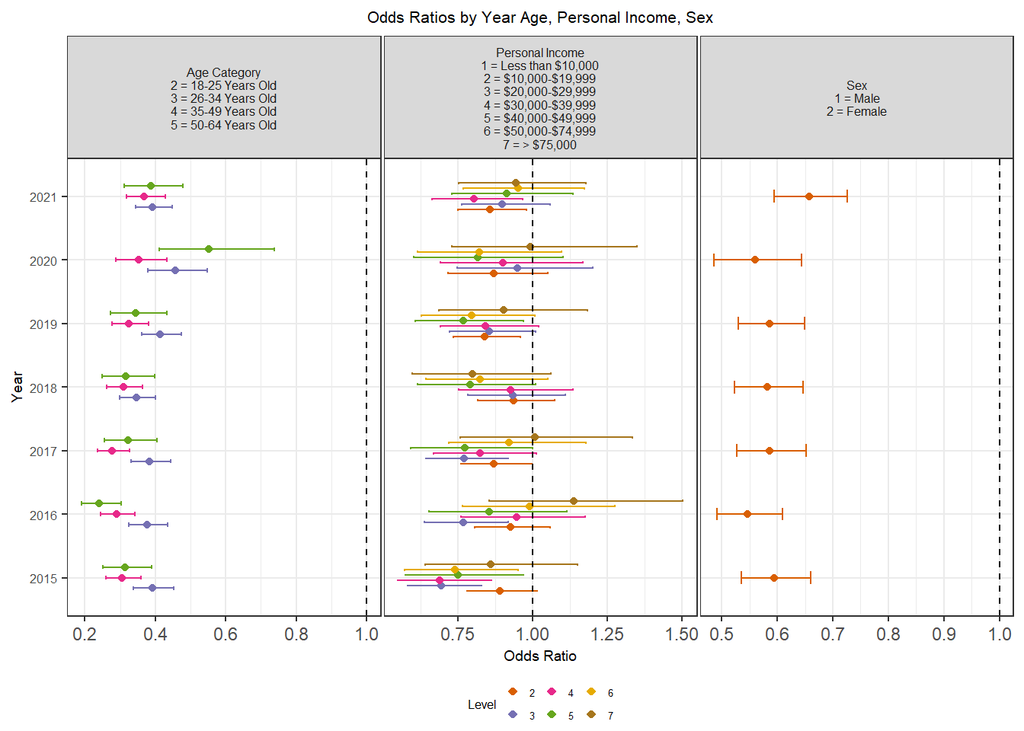

```r
# Ensure YEAR is a factor
combined_nsduh_sv <- combined_nsduh_sv |>
  mutate(YEAR = factor(YEAR))

# Ensure IRPINC3 now includes 1-7
combined_nsduh_sv <- combined_nsduh_sv |>
  mutate(
    CATAG6 = factor(CATAG6, levels = c("2", "3", "4", "5")),
    IRSEX = factor(IRSEX, levels = c("1", "2")),
    IRPINC3 = factor(IRPINC3, levels = c("1", "2", "3", "4", "5", "6", "7")),
    EDUHIGHCAT = factor(EDUHIGHCAT, levels = c("1", "2", "3", "4", "5")),
    IRMARIT = factor(IRMARIT, levels = c("1", "2", "3", "4")),
    ILLYR = factor(ILLYR, levels = c("0", "1")),
    IRPYUD5ALC = factor(IRPYUD5ALC, levels = c("0", "1")),
    IRAMDEYR = factor(IRAMDEYR, levels = c("0", "1")),
    MICATPY = factor(MICATPY, levels = c("0", "1", "2", "3"))
  )

# Combine all variable mappings
variable_mappings <- list(
  CATAG6 = list(
    levels = c("2", "3", "4", "5"),
    code_to_label = c(
      "2" = "18-25 Years Old",
      "3" = "26-34 Years Old",
      "4" = "35-49 Years Old",
      "5" = "50-64 Years Old"
    ),
    variable_label = "Age Category",
    ref_level = "2",
    code_mappings = "2 = 18-25 Years Old\n3 = 26-34 Years Old\n4 = 35-49 Years Old\n5 = 50-64 Years Old"
  ),
  IRSEX = list(
    levels = c("1", "2"),
    code_to_label = c(
      "1" = "Male",
      "2" = "Female"
    ),
    variable_label = "Sex",
    ref_level = "1",
    code_mappings = "1 = Male\n2 = Female"
  ),
  IRPINC3 = list(
    levels = c("1", "2", "3", "4", "5", "6", "7"),
    code_to_label = c(
      "1" = "Less than $10,000",
      "2" = "$10,000-$19,999",
      "3" = "$20,000-$29,999",
      "4" = "$30,000-$39,999",
      "5" = "$40,000-$49,999",
      "6" = "$50,000-$74,999",
      "7" = "> $75,000"
    ),
    variable_label = "Personal Income",
    ref_level = "1",
    code_mappings = "1 = Less than $10,000\n2 = $10,000-$19,999\n3 = $20,000-$29,999\n4 = $30,000-$39,999\n5 = $40,000-$49,999\n6 = $50,000-$74,999\n7 = > $75,000"
  ),
  EDUHIGHCAT = list(
    levels = c("1", "2", "3", "4", "5"),
    code_to_label = c(
      "1" = "< High school",
      "2" = "High school",
      "3" = "College/Associate degree",
      "4" = "College graduate",
      "5" = "12-17 year olds"
    ),
    variable_label = "Education Attainment",
    ref_level = "1",
    code_mappings = "1 = < High school\n2 = High school\n3 = College/Associate degree\n4 = College graduate\n5 = 12-17 year olds"
  ),
  IRMARIT = list(
    levels = c("1", "2", "3", "4"),
    code_to_label = c(
      "1" = "Married",
      "2" = "Widowed",
      "3" = "Divorced or Separated",
      "4" = "Never Been Married"
    ),
    variable_label = "Marital Status",
    ref_level = "1",
    code_mappings = "1 = Married\n2 = Widowed\n3 = Divorced or Separated\n4 = Never Been Married"
  ),
  ILLYR = list(
    levels = c("0", "1"),
    code_to_label = c(
      "0" = "No",
      "1" = "Yes"
    ),
    variable_label = "Illicit Drug Use",
    ref_level = "0",
    code_mappings = "0 = No\n1 = Yes"
  ),
  IRPYUD5ALC = list(
    levels = c("0", "1"),
    code_to_label = c(
      "0" = "No",
      "1" = "Yes"
    ),
    variable_label = "Alcohol Disorder",
    ref_level = "0",
    code_mappings = "0 = No\n1 = Yes"
  ),
  IRAMDEYR = list(
    levels = c("0", "1"),
    code_to_label = c(
      "0" = "No",
      "1" = "Yes"
    ),
    variable_label = "Major Depression",
    ref_level = "0",
    code_mappings = "0 = No\n1 = Yes"
  ),
  MICATPY = list(
    levels = c("0", "1", "2", "3"),
    code_to_label = c(
      "0" = "No",
      "1" = "Mild",
      "2" = "Moderate",
      "3" = "Serious"
    ),
    variable_label = "Mental Illness",
    ref_level = "0",
    code_mappings = "0 = No\n1 = Mild\n2 = Moderate\n3 = Serious"
  )
)

# Baseline formula
baseline_formula <- as.formula(
  "SI_VB ~ CATAG6 + IRSEX + IRPINC3 + EDUHIGHCAT + IRMARIT + ILLYR + IRPYUD5ALC + IRAMDEYR + MICATPY + NEWRACE2 + IRWRKSTAT18 + IRINSUR4 + UD5ILLANY"
)

year_range <- 2015:2021

extract_or_data <- function(model, var_name, mapping, YEAR_val) {
  coef_mat <- coef(summary(model))
  conf_mat <- confint(model)

  est_df <- data.frame(
    term = rownames(coef_mat),
    estimate = coef_mat[, "Estimate"],
    std_error = coef_mat[, "Std. Error"],
    conf_low = conf_mat[, 1],
    conf_high = conf_mat[, 2],
    stringsAsFactors = FALSE
  )

  est_df$OR <- exp(est_df$estimate)
  est_df$OR_lower <- exp(est_df$conf_low)
  est_df$OR_upper <- exp(est_df$conf_high)

  var_label <- mapping$variable_label
  code_map <- mapping$code_to_label
  ref_level <- mapping$ref_level

  var_levels <- setdiff(mapping$levels, ref_level)

  results_list <- lapply(var_levels, function(lvl) {
    term_name <- paste0(var_name, lvl)
    row_idx <- which(est_df$term == term_name)
    if (length(row_idx) == 1) {
      data.frame(
        YEAR = as.factor(YEAR_val),
        Variable_Name = var_name,
        Variable = var_label,
        Variable_with_codes = paste0(var_label, "\n", mapping$code_mappings),
        Level = lvl,
        Level_Label = code_map[lvl],
        OR = est_df$OR[row_idx],
        Lower_CI = est_df$OR_lower[row_idx],
        Upper_CI = est_df$OR_upper[row_idx],
        stringsAsFactors = FALSE
      )
    } else {
      data.frame(
        YEAR = as.factor(YEAR_val),
        Variable_Name = var_name,
        Variable = var_label,
        Variable_with_codes = paste0(var_label, "\n", mapping$code_mappings),
        Level = lvl,
        Level_Label = code_map[lvl],
        OR = 1,
        Lower_CI = 1,
        Upper_CI = 1,
        stringsAsFactors = FALSE
      )
    }
  })

  do.call(rbind, results_list)
}

# List of all variables for OR extraction
all_vars <- c("CATAG6", "IRSEX", "IRPINC3", "EDUHIGHCAT", "IRMARIT", "ILLYR", "IRPYUD5ALC", "IRAMDEYR", "MICATPY")

plot_data_list <- list()

for (yr in year_range) {
  data_year <- combined_nsduh_sv |>
    filter(YEAR == yr)

  model_year <- glm(baseline_formula, data = data_year, family = binomial())

  var_data_list <- lapply(all_vars, function(v) {
    extract_or_data(model_year, v, variable_mappings[[v]], yr)
  })

  year_data <- do.call(rbind, var_data_list)
  plot_data_list[[as.character(yr)]] <- year_data
}

plot_data <- do.call(rbind, plot_data_list)

# Define a function to create plots
make_forest_plot <- function(data, vars_to_plot, title_suffix) {
  sub_data <- data |> filter(Variable_Name %in% vars_to_plot)

  # Define colors
  # Extract all unique levels
  unique_levels <- sort(unique(as.numeric(sub_data$Level)))

  color_palette <- c("#1b9e77","#d95f02","#7570b3","#e7298a","#66a61e","#e6ab02","#a6761d")

  ggplot(sub_data, aes(y = YEAR, x = OR, xmin = Lower_CI, xmax = Upper_CI, color = factor(Level))) +
    geom_point(position = position_dodge(width = 0.5), size = 1.5) +
    geom_errorbarh(position = position_dodge(width = 0.5), height = 0.2) +
    facet_wrap(~ Variable_with_codes, scales = "free_x") +
    geom_vline(xintercept = 1, linetype = "dashed") +
    labs(
      title = paste0("Odds Ratios by Year ", title_suffix),
      x = "Odds Ratio",
      y = "Year",
      color = "Level"
    ) +
    theme_bw() +
    theme(
      strip.text = element_text(size = 6),
      strip.background = element_rect(linewidth = 0.5),
      panel.spacing = unit(0.1, "lines"),
      plot.margin = margin(t = 5, r = 5, b = 5, l = 5),
      axis.text.y = element_text(vjust = 0.5, size = 6),
      axis.title.x = element_text(size = 7),
      axis.title.y = element_text(size = 7),
      plot.title = element_text(hjust = 0.5, size = 8),
      legend.position = "bottom",
      legend.title = element_text(size = 6),
      legend.text = element_text(size = 5),
      legend.key.size = unit(0.2, "cm"),
      legend.margin = margin(0.1, 0.1, 0.1, 0.1),
      legend.box.margin = margin(0.1, 0.1, 0.1, 0.1)
    ) +
    scale_color_manual(values = color_palette[unique_levels])
}

# Plot 1: CATAG6, IRSEX, IRPINC3
plot1 <- make_forest_plot(plot_data, c("CATAG6", "IRSEX", "IRPINC3"), "Age, Personal Income, Sex")

# Plot 2: EDUHIGHCAT, IRMARIT, ILLYR
plot2 <- make_forest_plot(plot_data, c("EDUHIGHCAT", "IRMARIT", "ILLYR"), "Education, Marital Status, Illicit Drug Use")

# Plot 3: IRPYUD5ALC, IRAMDEYR, MICATPY
plot3 <- make_forest_plot(plot_data, c("IRPYUD5ALC", "IRAMDEYR", "MICATPY"), "Alcohol Disorder, Major Depression, Mental Illness")

# To display the plots:
print(plot1)
```

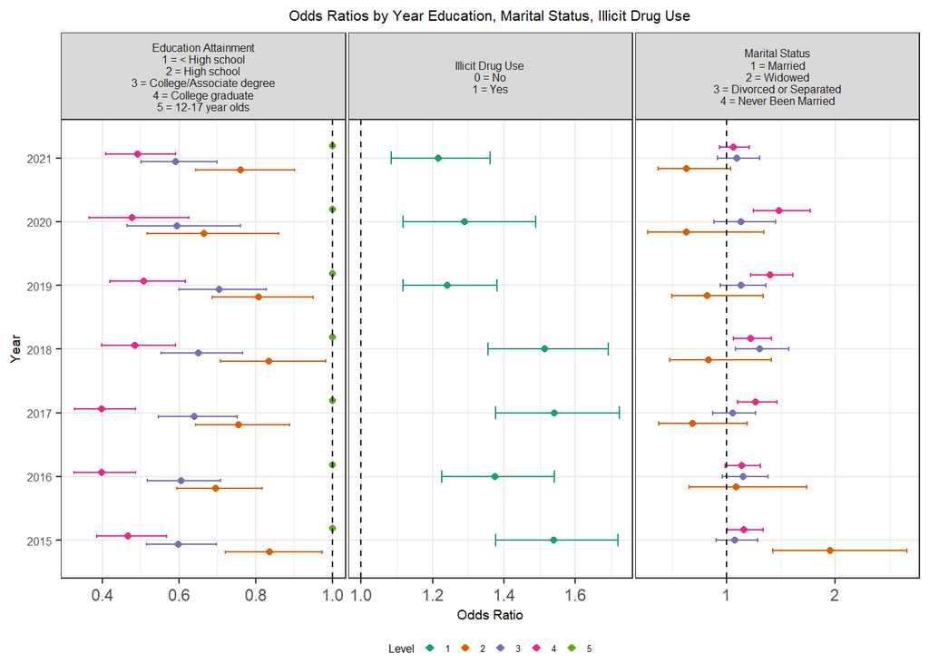

```r
print(plot2)
```

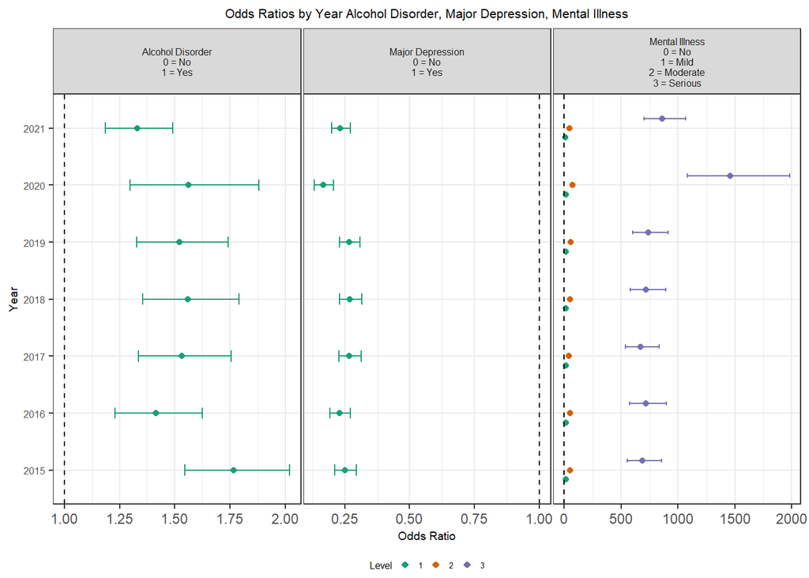

```r
print(plot3)
```

**Interpretation**

The most common reason for not seeking treatment is “cost barrier,” followed by “do not know where to get treatment,” “thought they could handle it on their own,” “worry about being committed to taking medication,” and “fear of commitment.”

In terms of demographic factors, older adults had significantly lower odds of suicidal ideation or violent behaviors (OR between 0.3126 and 0.3878). Females had lower odds compared to males (OR = 0.5896). Compared to White individuals, all other ethnic minorities had higher odds, with Native American/Alaskan Native individuals having had the highest odds (OR = 1.9273). Regarding socioeconomic factors, higher education levels had been associated with lower odds of the outcome, whereas unemployment had increased the odds (OR = 1.4044). The associations of personal income (ORs ranged from 0.8068 to 0.9462), marital status (OR between 1.0948 and 1.2242), and health insurance coverage (OR = 1.1296) had been weak. Illicit drug use ( OR = 1.3963) and substance use disorders –Alcohol disorder (OR = 1.51) ; Drug Disorder (OR = 1.2520) had been associated with increased odds of suicidal ideation or violent behaviors (SI/VB). The odds of SI/VB had increased dramatically with the severity of mental illness (Mild OR: 12.90; Moderate OR: 49.14; Serious OR: 761.58). Surprisingly, Major Depression had negative association with SIVB outcome (OR = 0.2444)

With the threshold of <2, there is no evidence of multicollinearity between the sociodemographic factors.

**Limitations**

This study has several limitations. First, as the data come from a self-report survey, this inevitably introduces social desirability bias or recall bias, which impacts the validity of the results. Second, due to the COVID-19 pandemic, the survey was conducted virtually in 2020 and 2021 rather than in person in previous years, which could cause mode effect bias. Third, suicidal ideation (SI) and violent behaviors (VB) were assessed based on a single question rather than using a specific psychometric instrument. Finally, some confounding factors, such as medical comorbidities or disabilities, were not controlled for in the study.

## 6 References

1.National Center for Injury Prevention and Control, Division of Violence Prevention. Principles of Prevention Guide. vetoviolence.cdc.gov. https://vetoviolence.cdc.gov/apps/pop/assets/pdfs/pop_notebook.pdf. Published September 1, 2019. Accessed November 11, 2024.

2.CDC. National violent death reporting system. National Violent Death Reporting System (NVDRS). https://www.cdc.gov/nvdrs/about/index.html. Published September 19, 2024. Accessed December 1, 2024.

3.Han B, Compton WM, Gfroerer J, McKeon R. Mental health treatment patterns among adults with recent suicide attempts in the United States. Am J Public Health. 2014;104(12):2359-2368. doi:10.2105/AJPH.2014.302163

4.Na PJ, Bommersbach TJ, Petrakis IL, Rhee TG. National trends of suicidal ideation and mental health services use among US adults with opioid use disorder, 2009-2020. EClinicalMedicine. 2022;54(101696):101696. doi:10.1016/j.eclinm.2022.101696

5.Choi NG, Marti CN, Choi BY. Mental health treatment use, perceived treatment need, and reasons for non-use among U.S. adults with serious suicidal thoughts during the COVID-19 pandemic. Community Ment Health J. 2024;60(5):972-984. doi:10.1007/s10597-024-01249-8

6.Substance Abuse and Mental Health Services Administration. Data files. Samhsa.gov. https://www.samhsa.gov/data/data-we-collect/nsduh/datafiles. Accessed November 23, 2024.